# 2011 and 2016 Census of Housing and Population Exploratory Analysis

21 April 2018

## Overview

The following code imports data from the 2011 and 2016 Census of Housing and Population for Australia.

```r
# Import: Indigenous Status by SA2 Level for each state (2011 Census)
sa2Data2011 <- importSA2Data("2011")

# Import: SA2 Level by Indigenous Status, Sex, Age in 10 year blocks, and Weekly Personal Income (2011 Census)
census2011 <- importCensusData("2011", "2011-Census-Analysis/data/2011_Census.csv", "D:/2011_Census.csv")
census2011$Year <- "2011"

# Import: Indigenous Status by SA2 Level for each state (2016 Census)
sa2Data2016 <- importSA2Data("2016")

# Import: SA2 Level by Indigenous Status, Sex, Age in 10 year blocks, and Weekly Personal Income (2016 Census)
census2016 <- importCensusData("2016", "2016-Census-Analysis/data/2016_Census.csv", "D:/2016_Census.csv")
census2016$Year <- "2016"

# Create new variable for Personal Weekly Income because they are different for 2011 and 2016 Census
uniqueCensus2011 <- unique(census2011$Weekly.Personal.Income)
uniqueCensus2016 <- unique(census2016$Weekly.Personal.Income)
setdiff(uniqueCensus2011, uniqueCensus2016) # Weekly Personal Income Values in 2011 not in 2016
```

```
## [1] "$1-$199"        "$200-$299"      "$400-$599"      "$600-$799"
## [5] "$1,500-$1,999"  "$2,000 or more"
```

```r
setdiff(uniqueCensus2016, uniqueCensus2011) # Weekly Personal Income Values in 2016 not in 2011
```

```
## [1] "$1-$149"        "$150-$299"      "$400-$499"      "$500-$649"
## [5] "$650-$799"      "$1,500-$1,749"  "$1,750-$1,999"  "$2,000-$2,999"
## [9] "$3,000 or more"
```

```r
intersect(uniqueCensus2011, uniqueCensus2016) # Shared values
```

```
## [1] "Not applicable"  "Nil income"      "$300-$399"       "$800-$999"
## [5] "Not stated"      "$1,000-$1,249"   "$1,250-$1,499"   "Negative income"
```

```r
# Not applicable
# Nil Income
# Negative Income
# Not stated
# $1-$299 ($1-$199 & $200-$299 from 2011 data; $1-$149 & $150-$299 from 2016 data)
# $300-$399
# $400-$799 ($400-$599 & $600-$799 from 2011 data; $400-$499, $500-$649 & $650-$799 from 2016 data)
# $800-$999
# $1,000-$1,249
# $1,250-$1,499
# $1,500-$1,999 ($1,500-$1,999 from 2011 data; $1,500-$1,749 & $1,750-$1,999 from 2016 data)
# $2,000 or more ($2,000 or more from 2011 data; $2,000-$2,999 & $3,000 or more from 2016 data)
census2011$Income <- as.character(census2011$Weekly.Personal.Income)
census2011$Income[census2011$Income == "$1-$199" | census2011$Income == "$200-$299"] <- "$1-$299"
census2011$Income[census2011$Income == "$400-$599" | census2011$Income == "$600-$799"] <- "$400-$799"

census2016$Income <- as.character(census2016$Weekly.Personal.Income)
census2016$Income[census2016$Income == "$1-$149" | census2016$Income == "$150-$299"] <- "$1-$299"
census2016$Income[census2016$Income == "$400-$499" | census2016$Income == "$500-$649" |
                    census2016$Income == "$650-$799"] <- "$400-$799"
census2016$Income[census2016$Income == "$1,500-$1,749" | census2016$Income == "$1,750-$1,999"] <- "$1,500-$1,999"
census2016$Income[census2016$Income == "$2,000-$2,999" | census2016$Income == "$3,000 or more"] <- "$2,000 or more"

census2011$Weekly.Personal.Income <- NULL
census2016$Weekly.Personal.Income <- NULL

# Aggregate rows that have been re-coded
attach(census2011)
census2011 <- aggregate(Count ~ . , sum, data=census2011)
detach(census2011)

attach(census2016)
census2016 <- aggregate(Count ~ . , sum, data=census2016)
detach(census2016)

# State population variable
state2011 <- aggregate(Count ~ State, sum, data=census2011)
colnames(state2011)[2] <- "StatePopulation"
census2011 <- merge(census2011, state2011, by="State")

state2016 <- aggregate(Count ~ State, sum, data=census2016)
colnames(state2016)[2] <- "StatePopulation"
census2016 <- merge(census2016, state2016, by="State")

# SA2 population variable
sa22011 <- aggregate(Count ~ SA2, sum, data=census2011)
colnames(sa22011)[2] <- "SA2Population"
census2011 <- merge(census2011, sa22011, by="SA2")

sa22016 <- aggregate(Count ~ SA2, sum, data=census2016)
colnames(sa22016)[2] <- "SA2Population"
census2016 <- merge(census2016, sa22016, by="SA2")

# Merge 2011 and 2016 data into one census dataset
census <- rbind(census2011, census2016)
census$Year <- as.factor(census$Year)
census$Income <- as.factor(census$Income)

# Re-order Age factor levels
census$Age = factor(census$Age,levels(census$Age)[c(1,2,4:11,3)])

# Re-order Income factor levels
census$Income = factor(census$Income,levels(census$Income)[c(11,12,9,10,1,6,7,8,2:5)])

# Add dummy variables for State, Income, Sex and Age variables
states <- as.data.frame(dummy.code(census$State))
ages <- as.data.frame(dummy.code(census$Age))
incomes <- as.data.frame(dummy.code(census$Income))
census <- cbind(census, states, ages, incomes)
census$Male <- as.numeric(census$Sex == "Male")
#census$Over50Years <-

rm(uniqueCensus2011, uniqueCensus2016, states, ages, incomes,
   census2011, census2016, sa22011, sa22016, state2011, state2016)

summary(census)   # When transforming the data counts of zero were excluded
```

```
##                              SA2             State             City
##  Mount Isa                     :   675   NSW    :244269   Min.   :0.000
##  Cape York                     :   650   QLD    :212474   1st Qu.:0.000
##  Broome                        :   647   VIC    :177017   Median :1.000
##  Innisfail                     :   646   WA     : 94412   Mean   :0.595
##  Grafton                       :   640   SA     : 65740   3rd Qu.:1.000
##  Malabar - La Perouse - Chifley:   634   TAS    : 36012   Max.   :1.000
##  (Other)                       :879089   (Other): 53057
##  InnerRegional    OuterRegional        Remote          VeryRemote
##  Min.   :0.0000   Min.   :0.0000   Min.   :0.00000   Min.   :0.0000
##  1st Qu.:0.0000   1st Qu.:0.0000   1st Qu.:0.00000   1st Qu.:0.0000
##  Median :0.0000   Median :0.0000   Median :0.00000   Median :0.0000
##  Mean   :0.2743   Mean   :0.1904   Mean   :0.06543   Mean   :0.0303
##  3rd Qu.:1.0000   3rd Qu.:0.0000   3rd Qu.:0.00000   3rd Qu.:0.0000
##  Max.   :1.0000   Max.   :1.0000   Max.   :1.00000   Max.   :1.0000
##
##  MigratoryOffshoreShipping NoUsualAddress
##  Min.   :0.0000000         Min.   :0.000000
##  1st Qu.:0.0000000         1st Qu.:0.000000
##  Median :0.0000000         Median :0.000000
##  Mean   :0.0003556         Mean   :0.003391
##  3rd Qu.:0.0000000         3rd Qu.:0.000000
##  Max.   :1.0000000         Max.   :1.000000
##
##                                   Indigenous.Status      Sex
##  Aboriginal                                : 98965   Female:441333
##  Both Aboriginal and Torres Strait Islander:  4400   Male  :441648
##  Non-Indigenous                            :657091
##  Not stated                                :117423
##  Torres Strait Islander                    :  5102
##
##
##           Age           Indigenous       Year               Income
##  20-29 years:119001   Min.   :0.0000   2011:434114   Not stated:143227
##  40-49 years:117333   1st Qu.:0.0000   2016:448867   $400-$799 : 99924
##  30-39 years:115497   Median :0.0000                 $1-$299   : 95652
##  50-59 years:114302   Mean   :0.1228                 $300-$399 : 91014
##  60-69 years:107400   3rd Qu.:0.0000                 Nil income: 75344
##  10-19 years:104054   Max.   :1.0000                 $800-$999 : 70663
##  (Other)    :205394                                  (Other)   :307157
```

[output cut: 57 more lines]

```
##  Min.   :0.0000   Min.   :0.0000   Min.   :0.00000   Min.   :0.00000
##  1st Qu.:0.0000   1st Qu.:0.0000   1st Qu.:0.00000   1st Qu.:0.00000
##  Median :0.0000   Median :0.0000   Median :0.00000   Median :0.00000
##  Mean   :0.1031   Mean   :0.1132   Mean   :0.08003   Mean   :0.07298
##  3rd Qu.:0.0000   3rd Qu.:0.0000   3rd Qu.:0.00000   3rd Qu.:0.00000
##  Max.   :1.0000   Max.   :1.0000   Max.   :1.00000   Max.   :1.00000
##
##  $1,250-$1,499     $1,500-$1,999     $2,000 or more         Male
##  Min.   :0.00000   Min.   :0.00000   Min.   :0.00000   Min.   :0.0000
##  1st Qu.:0.00000   1st Qu.:0.00000   1st Qu.:0.00000   1st Qu.:0.0000
##  Median :0.00000   Median :0.00000   Median :0.00000   Median :1.0000
##  Mean   :0.06165   Mean   :0.06045   Mean   :0.05754   Mean   :0.5002
##  3rd Qu.:0.00000   3rd Qu.:0.00000   3rd Qu.:0.00000   3rd Qu.:1.0000
##  Max.   :1.00000   Max.   :1.00000   Max.   :1.00000   Max.   :1.0000
##
```

```r
describe(census$Count, IQR=TRUE)
```

```
##    vars      n  mean    sd median trimmed   mad min  max range skew
## X1    1 882981 50.38 98.91     20   30.51 23.72   3 3770  3767 7.49
##    kurtosis   se IQR
## X1   100.54 0.11  49
```

```r
# Create data set containing only the Indigenous population
censusIndigenous <- census[which(census$Indigenous == 1),]
censusIndigenous$Indigenous <- NULL
censusIndigenous$Indigenous.Status <- NULL
attach(censusIndigenous)
censusIndigenous <- aggregate(Count ~ . , sum, data=censusIndigenous)
detach(censusIndigenous)

summary(censusIndigenous)   # When transforming the data counts of zero were excluded
```

```
##                      SA2            State            City
##  Broome                :  244   NSW    :34642   Min.   :0.00
##  Mount Isa             :  241   QLD    :27366   1st Qu.:0.00
##  Derby - West Kimberley:  234   WA     :11995   Median :0.00
##  Port Augusta          :  228   VIC    : 8693   Mean   :0.44
##  Kununurra             :  222   SA     : 6140   3rd Qu.:1.00
##  Katherine             :  221   NT     : 5899   Max.   :1.00
##  (Other)               :99201   (Other): 5856
##  InnerRegional    OuterRegional        Remote         VeryRemote
##  Min.   :0.0000   Min.   :0.0000   Min.   :0.0000   Min.   :0.00000
##  1st Qu.:0.0000   1st Qu.:0.0000   1st Qu.:0.0000   1st Qu.:0.00000
##  Median :0.0000   Median :0.0000   Median :0.0000   Median :0.00000
##  Mean   :0.2917   Mean   :0.2556   Mean   :0.1426   Mean   :0.08114
##  3rd Qu.:1.0000   3rd Qu.:1.0000   3rd Qu.:0.0000   3rd Qu.:0.00000
##  Max.   :1.0000   Max.   :1.0000   Max.   :1.0000   Max.   :1.00000
##
##  MigratoryOffshoreShipping NoUsualAddress         Sex
##  Min.   :0.00e+00          Min.   :0.000000   Female:51053
##  1st Qu.:0.00e+00          1st Qu.:0.000000   Male  :49538
##  Median :0.00e+00          Median :0.000000
##  Mean   :2.98e-05          Mean   :0.005766
##  3rd Qu.:0.00e+00          3rd Qu.:0.000000
##  Max.   :1.00e+00          Max.   :1.000000
##
##           Age          Year                  Income      StatePopulation
##  10-19 years:20383   2011:48395   $1-$299       :16849   Min.   :   2754
##  20-29 years:19482   2016:52196   $400-$799     :16713   1st Qu.:2450149
##  40-49 years:15826                Not applicable:14471   Median :4644165
##  30-39 years:15812                $300-$399     :12221   Mean   :4583480
##  50-59 years:12116                Nil income    : 8099   3rd Qu.:6867016
##  0-9 years  : 7658                Not stated    : 7920   Max.   :7416232
##  (Other)    : 9314                (Other)       :24318
##  SA2Population        ACT               NSW               NT
##  Min.   :    3   Min.   :0.00000   Min.   :0.0000   Min.   :0.00000
##  1st Qu.: 5995   1st Qu.:0.00000   1st Qu.:0.0000   1st Qu.:0.00000
##  Median :10050   Median :0.00000   Median :0.0000   Median :0.00000
##  Mean   :11374   Mean   :0.01287   Mean   :0.3444   Mean   :0.05864
##  3rd Qu.:15946   3rd Qu.:0.00000   3rd Qu.:1.0000   3rd Qu.:0.00000
##  Max.   :38203   Max.   :1.00000   Max.   :1.0000   Max.   :1.00000
##
```

[output cut: 49 more lines]

```
##  Min.   :0.0000   Min.   :0.00000   Min.   :0.00000   Min.   :0.00000
##  1st Qu.:0.0000   1st Qu.:0.00000   1st Qu.:0.00000   1st Qu.:0.00000
##  Median :0.0000   Median :0.00000   Median :0.00000   Median :0.00000
##  Mean   :0.1661   Mean   :0.07584   Mean   :0.06621   Mean   :0.03685
##  3rd Qu.:0.0000   3rd Qu.:0.00000   3rd Qu.:0.00000   3rd Qu.:0.00000
##  Max.   :1.0000   Max.   :1.00000   Max.   :1.00000   Max.   :1.00000
##
##  $1,500-$1,999     $2,000 or more         Male            Count
##  Min.   :0.00000   Min.   :0.00000   Min.   :0.0000   Min.   :  3.000
##  1st Qu.:0.00000   1st Qu.:0.00000   1st Qu.:0.0000   1st Qu.:  3.000
##  Median :0.00000   Median :0.00000   Median :0.0000   Median :  4.000
##  Mean   :0.03604   Mean   :0.02202   Mean   :0.4925   Mean   :  9.941
##  3rd Qu.:0.00000   3rd Qu.:0.00000   3rd Qu.:1.0000   3rd Qu.:  9.000
##  Max.   :1.00000   Max.   :1.00000   Max.   :1.0000   Max.   :800.000
##
```

```r
describe(censusIndigenous$Count, IQR=TRUE)
```

```
##    vars      n mean    sd median trimmed  mad min max range  skew kurtosis
## X1    1 100591 9.94 20.41      4    5.92 1.48   3 800   797 10.19   180.88
##      se IQR
## X1 0.06   6
```

```r
# Indigenous population data (2011 only)
censusIndigenous2011 <- censusIndigenous[which(censusIndigenous$Year == "2011"),]
censusIndigenous2011$Year <- NULL
censusIndigenous2011$Male <- NULL

# Indigenous population data (2016 only)
censusIndigenous2016 <- censusIndigenous[which(censusIndigenous$Year == "2016"),]
censusIndigenous2016$Year <- NULL
censusIndigenous2016$Male <- NULL

rm(importCensusData, importSA2byState, importSA2Data)
save(censusIndigenous2011, censusIndigenous2016, file="./Processed-Data/CensusData.RData")
```

### SA2 Level (2011 Census)

```r
dim(sa2Data2011) # data frame dimensions
```

```
## [1] 2214    8
```

```r
str(sa2Data2011) # structure of data
```

```
## 'data.frame':    2214 obs. of  8 variables:
##  $ SA2                                       : Factor w/ 2219 levels "ACT - East","ACT - South West",..: 6 8 12 17 23 31 32 36 37 41 ...
##  $ Non-Indigenous                            : int  18 69 94 41 38 99 87 79 56 14 ...
##  $ Aboriginal                                : int  12 55 50 91 19 135 48 41 43 18 ...
##  $ Torres Strait Islander                    : int  0 0 3 0 3 6 0 0 0 0 ...
##  $ Both Aboriginal and Torres Strait Islander: int  0 0 0 4 0 6 0 0 0 0 ...
##  $ Not stated                                : int  153 501 828 175 98 167 114 189 271 40 ...
##  $ Total                                     : int  2483 4436 6390 3069 2903 7111 5412 5040 3556 2121 ...
##  $ State                                     : Factor w/ 9 levels "ACT","NSW","NT",..: 1 1 1 1 1 1 1 1 1 1 ...
```

```r
head(sa2Data2011)
```

```
##         SA2 Non-Indigenous Aboriginal Torres Strait Islander
## 2    Aranda             18         12                      0
## 3 Belconnen             69         55                      0
## 4     Bruce             94         50                      3
## 5 Charnwood             41         91                      0
## 6      Cook             38         19                      3
## 7    Dunlop             99        135                      6
##   Both Aboriginal and Torres Strait Islander Not stated Total State
## 2                                          0        153  2483   ACT
## 3                                          0        501  4436   ACT
## 4                                          0        828  6390   ACT
## 5                                          4        175  3069   ACT
## 6                                          0         98  2903   ACT
## 7                                          6        167  7111   ACT
```

```r
summary(sa2Data2011)
```

```
##                SA2       Non-Indigenous    Aboriginal
##  ACT - East      :   1   Min.   :  2.0   Min.   :   0.0
##  ACT - South West:   1   1st Qu.: 65.0   1st Qu.:  46.0
##  Acton           :   1   Median :158.0   Median : 112.0
##  Ainslie         :   1   Mean   :192.6   Mean   : 224.0
##  Amaroo          :   1   3rd Qu.:308.8   3rd Qu.: 251.8
##  Aranda          :   1   Max.   :531.0   Max.   :6644.0
##  (Other)         :2208
##  Torres Strait Islander Both Aboriginal and Torres Strait Islander
##  Min.   :   0.00        Min.   :  0.000
##  1st Qu.:   0.00        1st Qu.:  0.000
##  Median :   5.00        Median :  3.000
##  Mean   :  14.09        Mean   :  9.466
##  3rd Qu.:  12.00        3rd Qu.:  8.000
##  Max.   :3302.00        Max.   :929.000
##
##    Not stated         Total           State
##  Min.   :   0.0   Min.   :    0   NSW    :540
##  1st Qu.: 202.0   1st Qu.: 4718   QLD    :528
##  Median : 374.0   Median : 8219   VIC    :435
##  Mean   : 478.1   Mean   : 9714   WA     :252
##  3rd Qu.: 636.8   3rd Qu.:13987   SA     :172
##  Max.   :4307.0   Max.   :38320   ACT    :112
##                                   (Other):175
```

```r
describe(sa2Data2011[c(2:7)], IQR=TRUE) # Summary statistics of population counts in each SA2 area
```

```
##                                            vars    n    mean      sd
## Non-Indigenous                                1 2214  192.59  147.01
## Aboriginal                                    2 2214  223.95  378.27
## Torres Strait Islander                        3 2214   14.09   85.07
## Both Aboriginal and Torres Strait Islander    4 2214    9.47   32.76
## Not stated                                    5 2214  478.15  418.48
## Total                                         6 2214 9714.44 6548.69
##                                            median trimmed     mad min
## Non-Indigenous                                158  181.01  161.60   2
## Aboriginal                                    112  149.28  120.09   0
## Torres Strait Islander                          5    6.60    7.41   0
## Both Aboriginal and Torres Strait Islander      3    4.23    4.45   0
## Not stated                                    374  417.53  300.97   0
## Total                                        8219 9142.22 6169.10   0
##                                              max range  skew kurtosis
## Non-Indigenous                               531   529  0.55    -0.89
## Aboriginal                                  6644  6644  6.02    60.52
## Torres Strait Islander                      3302  3302 29.93  1067.59
## Both Aboriginal and Torres Strait Islander   929   929 14.93   332.97
## Not stated                                  4307  4307  2.35     9.94
## Total                                      38320 38320  0.80     0.20
##                                                se     IQR
## Non-Indigenous                               3.12  243.75
## Aboriginal                                   8.04  205.75
## Torres Strait Islander                       1.81   12.00
## Both Aboriginal and Torres Strait Islander   0.70    8.00
## Not stated                                   8.89  434.75
## Total                                      139.18 9269.25
```

```r
count(sa2Data2011, 'State') # Number of SA2 areas in each state
```

```
##   State freq
## 1   ACT  112
## 2   NSW  540
## 3    NT   70
## 4 OTHER    5
## 5   QLD  528
## 6    SA  172
## 7   TAS  100
## 8   VIC  435
## 9    WA  252
```

```r
sum(count(sa2Data2011, 'State')$freq) # Number of SA2 areas in Australia for 2011 Census
```

```
## [1] 2214
```

### 2011 Census Data

```r
census2011 <- census[which(census$Year == "2011"),]
dim(census2011) # data frame dimensions
```

```
## [1] 434114     51
```

```r
str(census2011) # structure of data
```

```
## 'data.frame':    434114 obs. of  51 variables:
##  $ SA2                      : Factor w/ 2314 levels "Abbotsford","Aberfoyle Park",..: 1 1 1 1 1 1 1 1 1 1 ...
##  $ State                    : Factor w/ 9 levels "ACT","NSW","NT",..: 8 8 8 8 8 8 8 8 8 8 ...
##  $ City                     : int  1 1 1 1 1 1 1 1 1 1 ...
##  $ InnerRegional            : int  0 0 0 0 0 0 0 0 0 0 ...
##  $ OuterRegional            : int  0 0 0 0 0 0 0 0 0 0 ...
##  $ Remote                   : int  0 0 0 0 0 0 0 0 0 0 ...
##  $ VeryRemote               : int  0 0 0 0 0 0 0 0 0 0 ...
##  $ MigratoryOffshoreShipping: int  0 0 0 0 0 0 0 0 0 0 ...
##  $ NoUsualAddress           : int  0 0 0 0 0 0 0 0 0 0 ...
##  $ Indigenous.Status        : Factor w/ 5 levels "Aboriginal","Both Aboriginal and Torres Strait Islander",..: 3 3 3 3 3 3 1 3 3 3 ...
##  $ Sex                      : Factor w/ 2 levels "Female","Male": 1 2 2 1 2 2 2 1 2 1 ...
##  $ Age                      : Factor w/ 11 levels "0-9 years","10-19 years",..: 4 5 4 4 8 3 1 4 2 2 ...
##  $ Indigenous               : int  0 0 0 0 0 0 1 0 0 0 ...
##  $ Year                     : Factor w/ 2 levels "2011","2016": 1 1 1 1 1 1 1 1 1 1 ...
```

[output cut: 37 more lines]

```r
head(census2011, n=5)
```

```
##          SA2 State City InnerRegional OuterRegional Remote VeryRemote
## 1 Abbotsford   VIC    1             0             0      0          0
## 2 Abbotsford   VIC    1             0             0      0          0
## 3 Abbotsford   VIC    1             0             0      0          0
## 4 Abbotsford   VIC    1             0             0      0          0
## 5 Abbotsford   VIC    1             0             0      0          0
##   MigratoryOffshoreShipping NoUsualAddress Indigenous.Status    Sex
## 1                         0              0    Non-Indigenous Female
## 2                         0              0    Non-Indigenous   Male
## 3                         0              0    Non-Indigenous   Male
## 4                         0              0    Non-Indigenous Female
## 5                         0              0    Non-Indigenous   Male
##           Age Indigenous Year     Income Count StatePopulation
## 1 30-39 years          0 2011 Nil income    22         5318494
## 2 40-49 years          0 2011  $800-$999    31         5318494
```

[output cut: 33 more lines]

```r
unique(census2011$State) # Levels of State variables
```

```
## [1] VIC   SA    ACT   TAS   NSW   QLD   NT    WA    OTHER
## Levels: ACT NSW NT OTHER QLD SA TAS VIC WA
```

```r
unique(census2011$Indigenous.Status) # Levels of Indigenous Status variable
```

```
## [1] Non-Indigenous
## [2] Aboriginal
## [3] Not stated
## [4] Torres Strait Islander
## [5] Both Aboriginal and Torres Strait Islander
## 5 Levels: Aboriginal ... Torres Strait Islander
```

```r
unique(census2011$Sex) # Levels of Sex variable
```

```
## [1] Female Male
## Levels: Female Male
```

```r
unique(census2011$Age) # Levels of Age variable
```

```
##  [1] 30-39 years        40-49 years        70-79 years
##  [4] 20-29 years        0-9 years          10-19 years
##  [7] 60-69 years        50-59 years        90-99 years
## [10] 80-89 years        100 years and over
## 11 Levels: 0-9 years 10-19 years 20-29 years 30-39 years ... 100 years and over
```

```r
unique(census2011$Income) # Levels of Weekly Personal Income variable
```

```
##  [1] Nil income      $800-$999       $300-$399       $400-$799
##  [5] $1-$299         $1,000-$1,249   Not applicable  $1,250-$1,499
##  [9] $1,500-$1,999   $2,000 or more  Not stated      Negative income
## 12 Levels: Not applicable Not stated Negative income ... $2,000 or more
```

```r
summary(census2011)   # When transforming the data counts of zero were excluded
```

```
##                   SA2             State             City
##  Mount Isa          :   349   NSW    :118748   Min.   :0.0000
##  Tweed Heads - South:   333   QLD    :105304   1st Qu.:0.0000
##  Innisfail          :   327   VIC    : 86238   Median :1.0000
##  St Marys - Colyton :   324   WA     : 47226   Mean   :0.5904
##  Grafton            :   323   SA     : 32671   3rd Qu.:1.0000
##  Mildura            :   323   TAS    : 17794   Max.   :1.0000
##  (Other)            :432135   (Other): 26133
##  InnerRegional   OuterRegional        Remote          VeryRemote
##  Min.   :0.000   Min.   :0.0000   Min.   :0.00000   Min.   :0.00000
##  1st Qu.:0.000   1st Qu.:0.0000   1st Qu.:0.00000   1st Qu.:0.00000
##  Median :0.000   Median :0.0000   Median :0.00000   Median :0.00000
##  Mean   :0.274   Mean   :0.1935   Mean   :0.06774   Mean   :0.03043
##  3rd Qu.:1.000   3rd Qu.:0.0000   3rd Qu.:0.00000   3rd Qu.:0.00000
##  Max.   :1.000   Max.   :1.0000   Max.   :1.00000   Max.   :1.00000
##
##  MigratoryOffshoreShipping NoUsualAddress
##  Min.   :0.0000000         Min.   :0.000000
##  1st Qu.:0.0000000         1st Qu.:0.000000
##  Median :0.0000000         Median :0.000000
##  Mean   :0.0004008         Mean   :0.003467
##  3rd Qu.:0.0000000         3rd Qu.:0.000000
##  Max.   :1.0000000         Max.   :1.000000
##
##                                   Indigenous.Status      Sex
##  Aboriginal                                : 47564   Female:216513
##  Both Aboriginal and Torres Strait Islander:  2123   Male  :217601
##  Non-Indigenous                            :320138
##  Not stated                                : 61585
##  Torres Strait Islander                    :  2704
##
##
##           Age          Indigenous       Year               Income
##  20-29 years:58680   Min.   :0.0000   2011:434114   Not stated: 69792
##  40-49 years:58604   1st Qu.:0.0000   2016:     0   $1-$299   : 50653
##  30-39 years:57582   Median :0.0000                 $400-$799 : 49223
##  50-59 years:56472   Mean   :0.1207                 $300-$399 : 46320
##  60-69 years:52777   3rd Qu.:0.0000                 Nil income: 36345
##  10-19 years:52133   Max.   :1.0000                 $800-$999 : 33854
##  (Other)    :97866                                  (Other)   :147927
```

[output cut: 57 more lines]

```
##  Min.   :0.0000   Min.   :0.0000   Min.   :0.00000   Min.   :0.00000
##  1st Qu.:0.0000   1st Qu.:0.0000   1st Qu.:0.00000   1st Qu.:0.00000
##  Median :0.0000   Median :0.0000   Median :0.00000   Median :0.00000
##  Mean   :0.1067   Mean   :0.1134   Mean   :0.07798   Mean   :0.06962
##  3rd Qu.:0.0000   3rd Qu.:0.0000   3rd Qu.:0.00000   3rd Qu.:0.00000
##  Max.   :1.0000   Max.   :1.0000   Max.   :1.00000   Max.   :1.00000
##
##  $1,250-$1,499     $1,500-$1,999     $2,000 or more         Male
##  Min.   :0.00000   Min.   :0.00000   Min.   :0.00000   Min.   :0.0000
##  1st Qu.:0.00000   1st Qu.:0.00000   1st Qu.:0.00000   1st Qu.:0.0000
##  Median :0.00000   Median :0.00000   Median :0.00000   Median :1.0000
##  Mean   :0.05959   Mean   :0.05858   Mean   :0.05544   Mean   :0.5013
##  3rd Qu.:0.00000   3rd Qu.:0.00000   3rd Qu.:0.00000   3rd Qu.:1.0000
##  Max.   :1.00000   Max.   :1.00000   Max.   :1.00000   Max.   :1.0000
##
```

```r
describe(census2011$Count, IQR=TRUE)
```

```
##    vars      n mean    sd median trimmed   mad min  max range skew
## X1    1 434114 49.1 97.59     18   29.23 22.24   3 3718  3715 7.34
##    kurtosis   se IQR
## X1    96.34 0.15  48
```

```r
sum(census2011$Count) # Number of people counted in 2011 Census
```

```
## [1] 21314397
```

```r
length(unique(census2011$SA2)) # Number of SA2 areas with population counts > 0
```

```
## [1] 2148
```

```r
length(unique(sa2Data2011$SA2)) - length(unique(census2011$SA2)) # Number of SA2 areas with no population recorded
```

```
## [1] 66
```

```r
sum(census2011$Remote != census2011$VeryRemote) # Remote and Very Remote not equal
```

```
## [1] 16199
```

```r
unique(census2011[c("City", "InnerRegional", "OuterRegional", "Remote", "VeryRemote",
                    "MigratoryOffshoreShipping", "NoUsualAddress")])
```

```
##        City InnerRegional OuterRegional Remote VeryRemote
## 1         1             0             0      0          0
## 475       0             1             0      0          0
## 601       0             0             1      0          0
## 1223      1             1             0      0          0
## 1772      0             0             1      1          1
## 2997      0             0             1      1          0
## 4612      0             1             1      0          0
## 6450      0             0             0      1          0
## 7960      0             0             0      1          1
## 62982     0             1             0      1          0
## 145049    1             0             0      1          0
## 152893    0             1             1      1          0
## 182947    1             0             1      0          0
## 249109    0             0             0      0          0
```

[output cut: 19 more lines]

```r
options(scipen=999) # Disable scientific notation
total <- sum(census2011$Count)
customFunction <- function(x) c(sum = sum(x), percent = (sum(x)/total)*100)

attach(census2011)

# Number of people counted in each SA2 area during 2011 Census
x <- aggregate(Count ~ SA2 , FUN = sum, data=census2011) # Entire population
describe(x$Count, IQR=TRUE)
```

```
##    vars    n   mean      sd median trimmed     mad min   max range skew
## X1    1 2148 9922.9 6408.76 8400.5  9301.5 6112.76   3 38203 38200 0.85
##    kurtosis     se  IQR
## X1     0.25 138.28 9160
```

```r
x <- aggregate(Count ~ SA2 , FUN = sum, data=census2011[Indigenous==1,]) # Indigenous
describe(x$Count, IQR=TRUE)
```

```
##    vars    n   mean     sd median trimmed    mad min  max range skew
## X1    1 2065 223.58 410.09     90  137.55 109.71   3 6755  6752 5.71
##    kurtosis   se IQR
## X1    52.75 9.02 214
```

```r
x <- aggregate(Count ~ SA2 , FUN = sum, data=census2011[Indigenous==0,]) # Non-Indigenous
describe(x$Count, IQR=TRUE)
```

```
##    vars    n    mean      sd median trimmed     mad min   max range skew
## X1    1 2147 9712.49 6399.02   8179 9103.96 6103.86   3 38002 37999 0.84
##    kurtosis    se  IQR
## X1     0.26 138.1 9135
```

```r
# Number of people by remotness area
aggregate(Count~ City + InnerRegional + OuterRegional + Remote + VeryRemote +
            MigratoryOffshoreShipping + NoUsualAddress, FUN = customFunction, data=census2011)
```

```
##    City InnerRegional OuterRegional Remote VeryRemote
## 1     1             0             0      0          0
## 2     0             1             0      0          0
## 3     1             1             0      0          0
## 4     0             0             1      0          0
## 5     1             0             1      0          0
## 6     0             1             1      0          0
## 7     1             1             1      0          0
## 8     0             0             0      1          0
## 9     1             0             0      1          0
## 10    0             1             0      1          0
## 11    0             0             1      1          0
## 12    0             1             1      1          0
## 13    0             0             0      1          1
## 14    0             0             1      1          1
```

[output cut: 36 more lines]

```r
# Number of people counted in each state during 2011 Census
aggregate(Count ~ State , FUN = customFunction, data=census2011)
```

```
##   State        Count.sum    Count.percent
## 1   ACT  351109.00000000       1.64728564
## 2   NSW 6867016.00000000      32.21773527
## 3    NT  206393.00000000       0.96832671
## 4 OTHER    2754.00000000       0.01292084
## 5   QLD 4281844.00000000      20.08897554
## 6    SA 1582573.00000000       7.42490158
## 7   TAS  486207.00000000       2.28112013
## 8   VIC 5318494.00000000      24.95258956
## 9    WA 2218007.00000000      10.40614473
```

```r
# Number of people by indigenous status
aggregate(Count ~ Indigenous.Status , FUN = customFunction, data=census2011)
```

```
##                            Indigenous.Status         Count.sum
## 1                                 Aboriginal   431881.00000000
## 2 Both Aboriginal and Torres Strait Islander    12114.00000000
## 3                             Non-Indigenous 19863267.00000000
## 4                                 Not stated   989445.00000000
## 5                     Torres Strait Islander    17690.00000000
##       Count.percent
## 1        2.02624076
## 2        0.05683482
## 3       93.19178488
## 4        4.64214399
## 5        0.08299555
```

```r
# Number of people who are indigenous or not
aggregate(Count ~ Indigenous , FUN = customFunction, data=census2011)
```

```
##   Indigenous       Count.sum   Count.percent
## 1          0 20852712.000000       97.833929
## 2          1   461685.000000        2.166071
```

```r
# Number of people by sex
aggregate(Count ~ Sex, FUN = customFunction, data=census2011)
```

```
##      Sex      Count.sum  Count.percent
## 1 Female 10777994.00000       50.56673
## 2   Male 10536403.00000       49.43327
```

```r
# Number of people by age range
aggregate(Count ~ Age, FUN = customFunction, data=census2011)
```

```
##                   Age         Count.sum     Count.percent
## 1           0-9 years 2771406.000000000      13.002507179
## 2         10-19 years 2756090.000000000      12.930649645
## 3         20-29 years 2948922.000000000      13.835352696
## 4         30-39 years 2948510.000000000      13.833419730
## 5         40-49 years 3019786.000000000      14.167822810
## 6         50-59 years 2719265.000000000      12.757879099
## 7         60-69 years 2104686.000000000       9.874480615
## 8         70-79 years 1236030.000000000       5.799038087
## 9         80-89 years  691810.000000000       3.245740426
## 10        90-99 years  116569.000000000       0.546902641
## 11 100 years and over    1323.000000000       0.006207072
```

```r
# Number of people by Weekly Personal Income
aggregate(Count ~ Income, FUN = customFunction, data=census2011)
```

```
##             Income       Count.sum   Count.percent
## 1   Not applicable 4140886.0000000      19.4276479
## 2       Not stated 1360116.0000000       6.3812080
## 3  Negative income   91064.0000000       0.4272417
## 4       Nil income 1299040.0000000       6.0946599
## 5          $1-$299 3048361.0000000      14.3018871
## 6        $300-$399 1697359.0000000       7.9634390
## 7        $400-$799 3770749.0000000      17.6910893
## 8        $800-$999 1421037.0000000       6.6670289
## 9    $1,000-$1,249 1357884.0000000       6.3707362
## 10   $1,250-$1,499  947832.0000000       4.4469098
## 11   $1,500-$1,999 1109445.0000000       5.2051437
## 12  $2,000 or more 1070624.0000000       5.0230086
```

```r
# Number of people per state by indigenous status
aggregate(Count ~ Indigenous + State, FUN = customFunction, data=census2011)
```

```
##    Indigenous State          Count.sum      Count.percent
## 1           0   ACT  348057.0000000000       1.6329666751
## 2           1   ACT    3052.0000000000       0.0143189601
## 3           0   NSW 6717695.0000000000      31.5171712341
## 4           1   NSW  149321.0000000000       0.7005640366
## 5           0    NT  152823.0000000000       0.7169942457
## 6           1    NT   53570.0000000000       0.2513324679
## 7           0 OTHER    2568.0000000000       0.0120481945
## 8           1 OTHER     186.0000000000       0.0008726496
## 9           0   QLD 4152374.0000000000      19.4815457364
## 10          1   QLD  129470.0000000000       0.6074298044
## 11          0    SA 1558033.0000000000       7.3097681347
## 12          1    SA   24540.0000000000       0.1151334471
## 13          0   TAS  471015.0000000000       2.2098443601
## 14          1   TAS   15192.0000000000       0.0712757673
## 15          0   VIC 5292883.0000000000      24.8324313374
## 16          1   VIC   25611.0000000000       0.1201582198
## 17          0    WA 2157264.0000000000      10.1211589519
## 18          1    WA   60743.0000000000       0.2849857775
```

```r
# Number of people per Indigenous Status by age range
aggregate(Count ~ Indigenous + Age, FUN = customFunction, data=census2011)
```

```
##    Indigenous                Age          Count.sum      Count.percent
## 1           0          0-9 years 2640336.0000000000      12.3875707110
## 2           1          0-9 years  131070.0000000000       0.6149364676
## 3           0        10-19 years 2643280.0000000000      12.4013829713
## 4           1        10-19 years  112810.0000000000       0.5292666736
## 5           0        20-29 years 2878566.0000000000      13.5052659477
## 6           1        20-29 years   70356.0000000000       0.3300867484
## 7           0        30-39 years 2896210.0000000000      13.5880456764
## 8           1        30-39 years   52300.0000000000       0.2453740540
## 9           0        40-49 years 2972547.0000000000      13.9461932702
## 10          1        40-49 years   47239.0000000000       0.2216295399
## 11          0        50-59 years 2689959.0000000000      12.6203851791
## 12          1        50-59 years   29306.0000000000       0.1374939202
## 13          0        60-69 years 2091422.0000000000       9.8122503771
## 14          1        60-69 years   13264.0000000000       0.0622302381
## 15          0        70-79 years 1231617.0000000000       5.7783337713
## 16          1        70-79 years    4413.0000000000       0.0207043155
## 17          0        80-89 years  690937.0000000000       3.2416446029
## 18          1        80-89 years     873.0000000000       0.0040958231
## 19          0        90-99 years  116515.0000000000       0.5466492906
## 20          1        90-99 years      54.0000000000       0.0002533499
## 21          0 100 years and over    1323.0000000000       0.0062070721
```

```r
# Number of people per Indigenous Status by Weekly Personal Income
aggregate(Count ~ Indigenous + Income, FUN = customFunction, data=census2011)
```

```
##    Indigenous          Income         Count.sum     Count.percent
## 1           0  Not applicable 3946692.000000000      18.516554796
## 2           1  Not applicable  194194.000000000       0.911093098
## 3           0      Not stated 1331223.000000000       6.245651707
## 4           1      Not stated   28893.000000000       0.135556263
## 5           0 Negative income   90344.000000000       0.423863739
## 6           1 Negative income     720.000000000       0.003377998
## 7           0      Nil income 1276408.000000000       5.988478116
## 8           1      Nil income   22632.000000000       0.106181751
## 9           0         $1-$299 2965971.000000000      13.915340884
## 10          1         $1-$299   82390.000000000       0.386546239
## 11          0       $300-$399 1663745.000000000       7.805733374
## 12          1       $300-$399   33614.000000000       0.157705611
## 13          0       $400-$799 3712112.000000000      17.415984135
## 14          1       $400-$799   58637.000000000       0.275105132
## 15          0       $800-$999 1406644.000000000       6.599501736
## 16          1       $800-$999   14393.000000000       0.067527127
## 17          0   $1,000-$1,249 1346611.000000000       6.317847040
## 18          1   $1,000-$1,249   11273.000000000       0.052889134
## 19          0   $1,250-$1,499  942299.000000000       4.420950778
## 20          1   $1,250-$1,499    5533.000000000       0.025958980
## 21          0   $1,500-$1,999 1103434.000000000       5.176942139
## 22          1   $1,500-$1,999    6011.000000000       0.028201595
## 23          0  $2,000 or more 1067229.000000000       5.007080425
## 24          1  $2,000 or more    3395.000000000       0.015928201
```

```r
# Number of people per Indigenous Status by Sex
aggregate(Count ~ Indigenous + Sex, FUN = customFunction, data=census2011)
```

```
##   Indigenous    Sex       Count.sum   Count.percent
## 1          0 Female 10543052.000000       49.464463
## 2          1 Female   234942.000000        1.102269
## 3          0   Male 10309660.000000       48.369466
## 4          1   Male   226743.000000        1.063802
```

```r
# Number of Indigenous people by state
total <- sum(census2011[Indigenous == 1,]$Count)
aggregate(Count ~ State , FUN = customFunction, data=census2011[Indigenous == 1,])
```

```
##   State       Count.sum   Count.percent
## 1   ACT   3052.00000000      0.66105678
## 2   NSW 149321.00000000     32.34261455
## 3    NT  53570.00000000     11.60314933
## 4 OTHER    186.00000000      0.04028721
## 5   QLD 129470.00000000     28.04292970
## 6    SA  24540.00000000      5.31531239
## 7   TAS  15192.00000000      3.29055525
## 8   VIC  25611.00000000      5.54728874
## 9    WA  60743.00000000     13.15680605
```

```r
# Number of Indigenous people by age range
aggregate(Count ~ Age , FUN = customFunction, data=census2011[Indigenous == 1,])
```

```
##            Age       Count.sum   Count.percent
## 1    0-9 years 131070.00000000     28.38948634
## 2  10-19 years 112810.00000000     24.43440874
## 3  20-29 years  70356.00000000     15.23896163
## 4  30-39 years  52300.00000000     11.32807000
## 5  40-49 years  47239.00000000     10.23186805
## 6  50-59 years  29306.00000000      6.34761796
## 7  60-69 years  13264.00000000      2.87295450
## 8  70-79 years   4413.00000000      0.95584652
## 9  80-89 years    873.00000000      0.18908996
## 10 90-99 years     54.00000000      0.01169629
```

```r
# Number of Indigenous people by income
aggregate(Count ~ Income , FUN = customFunction, data=census2011[Indigenous == 1,])
```

```
##             Income      Count.sum  Count.percent
## 1   Not applicable 194194.0000000     42.0620120
## 2       Not stated  28893.0000000      6.2581630
## 3  Negative income    720.0000000      0.1559505
## 4       Nil income  22632.0000000      4.9020436
## 5          $1-$299  82390.0000000     17.8455007
## 6        $300-$399  33614.0000000      7.2807217
## 7        $400-$799  58637.0000000     12.7006509
## 8        $800-$999  14393.0000000      3.1174935
## 9    $1,000-$1,249  11273.0000000      2.4417081
## 10   $1,250-$1,499   5533.0000000      1.1984362
## 11   $1,500-$1,999   6011.0000000      1.3019700
## 12  $2,000 or more   3395.0000000      0.7353499
```

```r
# Number of Indigenous people by remotness area
aggregate(Count ~ City + InnerRegional + OuterRegional + Remote + VeryRemote +
            MigratoryOffshoreShipping + NoUsualAddress, FUN = customFunction, data=census2011[Indigenous == 1,])
```

```
##    City InnerRegional OuterRegional Remote VeryRemote
## 1     1             0             0      0          0
## 2     0             1             0      0          0
## 3     1             1             0      0          0
## 4     0             0             1      0          0
## 5     1             0             1      0          0
## 6     0             1             1      0          0
## 7     1             1             1      0          0
## 8     0             0             0      1          0
## 9     1             0             0      1          0
## 10    0             1             0      1          0
## 11    0             0             1      1          0
## 12    0             1             1      1          0
## 13    0             0             0      1          1
## 14    0             0             1      1          1
```

[output cut: 33 more lines]

```r
# Number of Non-Indigenous people by state
total <- sum(census2011[Indigenous == 0,]$Count)
aggregate(Count ~ State , FUN = customFunction, data=census2011[Indigenous == 0,])
```

```
##   State        Count.sum    Count.percent
## 1   ACT  348057.00000000       1.66912102
## 2   NSW 6717695.00000000      32.21497041
## 3    NT  152823.00000000       0.73286870
## 4 OTHER    2568.00000000       0.01231494
## 5   QLD 4152374.00000000      19.91287272
## 6    SA 1558033.00000000       7.47160849
## 7   TAS  471015.00000000       2.25877095
## 8   VIC 5292883.00000000      25.38222846
## 9    WA 2157264.00000000      10.34524430
```

```r
# Number of Non-Indigenous people by age range
aggregate(Count ~ Age , FUN = customFunction, data=census2011[Indigenous == 0,])
```

```
##                   Age         Count.sum     Count.percent
## 1           0-9 years 2640336.000000000      12.661835065
## 2         10-19 years 2643280.000000000      12.675953133
## 3         20-29 years 2878566.000000000      13.804276393
## 4         30-39 years 2896210.000000000      13.888888889
## 5         40-49 years 2972547.000000000      14.254965973
## 6         50-59 years 2689959.000000000      12.899804112
## 7         60-69 years 2091422.000000000      10.029496403
## 8         70-79 years 1231617.000000000       5.906267732
## 9         80-89 years  690937.000000000       3.313415540
## 10        90-99 years  116515.000000000       0.558752262
## 11 100 years and over    1323.000000000       0.006344498
```

```r
# Number of Non-Indigenous people by income
aggregate(Count ~ Income , FUN = customFunction, data=census2011[Indigenous == 0,])
```

```
##             Income       Count.sum   Count.percent
## 1   Not applicable 3946692.0000000      18.9265166
## 2       Not stated 1331223.0000000       6.3839322
## 3  Negative income   90344.0000000       0.4332482
## 4       Nil income 1276408.0000000       6.1210647
## 5          $1-$299 2965971.0000000      14.2234305
## 6        $300-$399 1663745.0000000       7.9785545
## 7        $400-$799 3712112.0000000      17.8015790
## 8        $800-$999 1406644.0000000       6.7456166
## 9    $1,000-$1,249 1346611.0000000       6.4577260
## 10   $1,250-$1,499  942299.0000000       4.5188319
## 11   $1,500-$1,999 1103434.0000000       5.2915611
## 12  $2,000 or more 1067229.0000000       5.1179386
```

```r
# Statistical Summary of Indigenous population count
describe(census2011[Indigenous == 1,]$Count, IQR=TRUE)
```

```
##    vars     n mean    sd median trimmed  mad min max range  skew kurtosis
## X1    1 52391 8.81 18.42      4    5.26 1.48   3 771   768 11.38   231.64
##      se IQR
## X1 0.08   5
```

```r
# Statistical Summary of Non-Indigenous population count
describe(census2011[Indigenous == 0,]$Count, IQR=TRUE)
```

```
##    vars      n  mean     sd median trimmed   mad min  max range skew
## X1    1 381723 54.63 102.62     23   34.01 28.17   3 3718  3715 7.02
##    kurtosis   se IQR
## X1    87.84 0.17  54
```

```r
detach(census2011)

rm(census2011, total, x)
options(scipen=0) # Enable scientific notation
```

### SA2 Level (2016 Census)

```r
dim(sa2Data2016) # data frame dimensions
```

```
## [1] 2310    8
```

```r
str(sa2Data2016) # structure of data
```

```
## 'data.frame':    2310 obs. of  8 variables:
##  $ SA2                                       : Factor w/ 2314 levels "ACT - South West",..: 5 9 14 21 27 36 38 42 43 47 ...
##  $ Non-Indigenous                            : int  25 104 110 42 39 112 91 83 64 17 ...
##  $ Aboriginal                                : int  19 75 49 93 35 147 90 70 54 32 ...
##  $ Torres Strait Islander                    : int  0 8 0 0 3 0 3 3 0 0 ...
##  $ Both Aboriginal and Torres Strait Islander: int  0 4 0 0 0 7 0 0 0 0 ...
##  $ Not stated                                : int  74 511 441 173 105 252 341 193 126 82 ...
##  $ Total                                     : int  2397 6651 6996 2979 2804 7199 5329 4769 3355 2027 ...
##  $ State                                     : Factor w/ 9 levels "ACT","NSW","NT",..: 1 1 1 1 1 1 1 1 1 1 ...
```

```r
head(sa2Data2016)
```

```
##         SA2 Non-Indigenous Aboriginal Torres Strait Islander
## 2    Aranda             25         19                      0
## 3 Belconnen            104         75                      8
## 4     Bruce            110         49                      0
## 5 Charnwood             42         93                      0
## 6      Cook             39         35                      3
## 7    Dunlop            112        147                      0
##   Both Aboriginal and Torres Strait Islander Not stated Total State
## 2                                          0         74  2397   ACT
## 3                                          4        511  6651   ACT
## 4                                          0        441  6996   ACT
## 5                                          0        173  2979   ACT
## 6                                          0        105  2804   ACT
## 7                                          7        252  7199   ACT
```

```r
summary(sa2Data2016)
```

```
##                SA2       Non-Indigenous    Aboriginal
##  ACT - South West:   1   Min.   :  2.0   Min.   :   0.0
##  Acton           :   1   1st Qu.: 68.0   1st Qu.:  58.0
##  Ainslie         :   1   Median :164.0   Median : 133.0
##  Amaroo          :   1   Mean   :201.2   Mean   : 255.5
##  Aranda          :   1   3rd Qu.:324.0   3rd Qu.: 295.8
##  Arboretum       :   1   Max.   :562.0   Max.   :6777.0
##  (Other)         :2304
##  Torres Strait Islander Both Aboriginal and Torres Strait Islander
##  Min.   :   0.00        Min.   :   0.00
##  1st Qu.:   0.00        1st Qu.:   0.00
##  Median :   5.00        Median :   4.00
##  Mean   :  13.89        Mean   :  11.47
##  3rd Qu.:  12.00        3rd Qu.:  10.00
##  Max.   :3588.00        Max.   :1390.00
##
##    Not stated         Total           State
##  Min.   :   0.0   Min.   :    0   NSW    :578
##  1st Qu.: 302.2   1st Qu.: 4861   QLD    :530
##  Median : 522.0   Median : 8786   VIC    :464
##  Mean   : 611.1   Mean   :10131   WA     :254
##  3rd Qu.: 804.0   3rd Qu.:14594   SA     :174
##  Max.   :4655.0   Max.   :37325   ACT    :133
##                                   (Other):177
```

```r
describe(sa2Data2011[c(2:7)], IQR=TRUE) # Summary statistics of population counts in each SA2 area
```

```
##                                            vars    n    mean      sd
## Non-Indigenous                                1 2214  192.59  147.01
## Aboriginal                                    2 2214  223.95  378.27
## Torres Strait Islander                        3 2214   14.09   85.07
## Both Aboriginal and Torres Strait Islander    4 2214    9.47   32.76
## Not stated                                    5 2214  478.15  418.48
## Total                                         6 2214 9714.44 6548.69
##                                            median trimmed     mad min
## Non-Indigenous                                158  181.01  161.60   2
## Aboriginal                                    112  149.28  120.09   0
## Torres Strait Islander                          5    6.60    7.41   0
## Both Aboriginal and Torres Strait Islander      3    4.23    4.45   0
## Not stated                                    374  417.53  300.97   0
## Total                                        8219 9142.22 6169.10   0
##                                              max range  skew kurtosis
## Non-Indigenous                               531   529  0.55    -0.89
## Aboriginal                                  6644  6644  6.02    60.52
## Torres Strait Islander                      3302  3302 29.93  1067.59
## Both Aboriginal and Torres Strait Islander   929   929 14.93   332.97
## Not stated                                  4307  4307  2.35     9.94
## Total                                      38320 38320  0.80     0.20
##                                                se     IQR
## Non-Indigenous                               3.12  243.75
## Aboriginal                                   8.04  205.75
## Torres Strait Islander                       1.81   12.00
## Both Aboriginal and Torres Strait Islander   0.70    8.00
## Not stated                                   8.89  434.75
## Total                                      139.18 9269.25
```

```r
count(sa2Data2016, 'State') # Number of SA2 areas in each state
```

```
##   State freq
## 1   ACT  133
## 2   NSW  578
## 3    NT   70
## 4 OTHER    6
## 5   QLD  530
## 6    SA  174
## 7   TAS  101
## 8   VIC  464
## 9    WA  254
```

```r
sum(count(sa2Data2016, 'State')$freq) # Number of SA2 areas in Australia for 2016 Census
```

```
## [1] 2310
```

### 2016 Census Data

```r
census2016 <- census[which(census$Year == "2016"),]
dim(census2016) # data frame dimensions
```

```
## [1] 448867     51
```

```r
str(census2016) # structure of data
```

```
## 'data.frame':    448867 obs. of  51 variables:
##  $ SA2                      : Factor w/ 2314 levels "Abbotsford","Aberfoyle Park",..: 1 1 1 1 1 1 1 1 1 1 ...
##  $ State                    : Factor w/ 9 levels "ACT","NSW","NT",..: 8 8 8 8 8 8 8 8 8 8 ...
##  $ City                     : int  1 1 1 1 1 1 1 1 1 1 ...
##  $ InnerRegional            : int  0 0 0 0 0 0 0 0 0 0 ...
##  $ OuterRegional            : int  0 0 0 0 0 0 0 0 0 0 ...
##  $ Remote                   : int  0 0 0 0 0 0 0 0 0 0 ...
##  $ VeryRemote               : int  0 0 0 0 0 0 0 0 0 0 ...
##  $ MigratoryOffshoreShipping: int  0 0 0 0 0 0 0 0 0 0 ...
##  $ NoUsualAddress           : int  0 0 0 0 0 0 0 0 0 0 ...
##  $ Indigenous.Status        : Factor w/ 5 levels "Aboriginal","Both Aboriginal and Torres Strait Islander",..: 3 3 3 3 3 3 4 3 3 3 ...
##  $ Sex                      : Factor w/ 2 levels "Female","Male": 1 2 1 1 2 2 2 2 1 2 ...
##  $ Age                      : Factor w/ 11 levels "0-9 years","10-19 years",..: 5 4 6 6 8 3 6 6 8 9 ...
##  $ Indigenous               : int  0 0 0 0 0 0 0 0 0 0 ...
##  $ Year                     : Factor w/ 2 levels "2011","2016": 2 2 2 2 2 2 2 2 2 2 ...
```

[output cut: 37 more lines]

```r
head(census2016, n=5)
```

```
##               SA2 State City InnerRegional OuterRegional Remote VeryRemote
## 434115 Abbotsford   VIC    1             0             0      0          0
## 434116 Abbotsford   VIC    1             0             0      0          0
## 434117 Abbotsford   VIC    1             0             0      0          0
## 434118 Abbotsford   VIC    1             0             0      0          0
## 434119 Abbotsford   VIC    1             0             0      0          0
##        MigratoryOffshoreShipping NoUsualAddress Indigenous.Status    Sex
## 434115                         0              0    Non-Indigenous Female
## 434116                         0              0    Non-Indigenous   Male
## 434117                         0              0    Non-Indigenous Female
## 434118                         0              0    Non-Indigenous Female
## 434119                         0              0    Non-Indigenous   Male
##                Age Indigenous Year        Income Count StatePopulation
## 434115 40-49 years          0 2016     $300-$399    16         5881465
## 434116 30-39 years          0 2016     $300-$399    14         5881465
```

[output cut: 39 more lines]

```r
unique(census2016$State) # Levels of State variable
```

```
## [1] VIC   SA    NSW   ACT   TAS   QLD   NT    WA    OTHER
## Levels: ACT NSW NT OTHER QLD SA TAS VIC WA
```

```r
unique(census2016$Indigenous.Status) # Levels of Indigenous Status variable
```

```
## [1] Non-Indigenous
## [2] Not stated
## [3] Aboriginal
## [4] Torres Strait Islander
## [5] Both Aboriginal and Torres Strait Islander
## 5 Levels: Aboriginal ... Torres Strait Islander
```

```r
unique(census2016$Sex) # Levels of Sex variable
```

```
## [1] Female Male
## Levels: Female Male
```

```r
unique(census2016$Age) # Levels of Age variable
```

```
##  [1] 40-49 years        30-39 years        50-59 years
##  [4] 70-79 years        20-29 years        80-89 years
##  [7] 10-19 years        0-9 years          60-69 years
## [10] 90-99 years        100 years and over
## 11 Levels: 0-9 years 10-19 years 20-29 years 30-39 years ... 100 years and over
```

```r
unique(census2016$Income) # Levels of Weekly Personal Income variable
```

```
##  [1] $300-$399       $1,000-$1,249   $1,250-$1,499   $2,000 or more
##  [5] Not stated      $800-$999       $1-$299         Negative income
##  [9] Nil income      Not applicable  $1,500-$1,999   $400-$799
## 12 Levels: Not applicable Not stated Negative income ... $2,000 or more
```

```r
summary(census2016)   # When transforming the data counts of zero were excluded
```

```
##         SA2             State             City        InnerRegional
##  Cape York:   345   NSW    :125521   Min.   :0.0000   Min.   :0.0000
##  Broome   :   330   QLD    :107170   1st Qu.:0.0000   1st Qu.:0.0000
##  Mount Isa:   326   VIC    : 90779   Median :1.0000   Median :0.0000
##  Taree    :   324   WA     : 47186   Mean   :0.5994   Mean   :0.2746
##  Armidale :   322   SA     : 33069   3rd Qu.:1.0000   3rd Qu.:1.0000
##  Nowra    :   321   TAS    : 18218   Max.   :1.0000   Max.   :1.0000
##  (Other)  :446899   (Other): 26924
##  OuterRegional        Remote          VeryRemote
##  Min.   :0.0000   Min.   :0.00000   Min.   :0.00000
##  1st Qu.:0.0000   1st Qu.:0.00000   1st Qu.:0.00000
##  Median :0.0000   Median :0.00000   Median :0.00000
##  Mean   :0.1873   Mean   :0.06319   Mean   :0.03017
##  3rd Qu.:0.0000   3rd Qu.:0.00000   3rd Qu.:0.00000
##  Max.   :1.0000   Max.   :1.00000   Max.   :1.00000
##
##  MigratoryOffshoreShipping NoUsualAddress
##  Min.   :0.0000000         Min.   :0.000000
##  1st Qu.:0.0000000         1st Qu.:0.000000
##  Median :0.0000000         Median :0.000000
##  Mean   :0.0003119         Mean   :0.003317
##  3rd Qu.:0.0000000         3rd Qu.:0.000000
##  Max.   :1.0000000         Max.   :1.000000
##
##                                   Indigenous.Status      Sex
##  Aboriginal                                : 51401   Female:224820
##  Both Aboriginal and Torres Strait Islander:  2277   Male  :224047
##  Non-Indigenous                            :336953
##  Not stated                                : 55838
##  Torres Strait Islander                    :  2398
##
##
##           Age           Indigenous       Year               Income
##  20-29 years: 60321   Min.   :0.0000   2011:     0   Not stated: 73435
##  40-49 years: 58729   1st Qu.:0.0000   2016:448867   $400-$799 : 50701
##  30-39 years: 57915   Median :0.0000                 $1-$299   : 44999
##  50-59 years: 57830   Mean   :0.1249                 $300-$399 : 44694
##  60-69 years: 54623   3rd Qu.:0.0000                 Nil income: 38999
##  10-19 years: 51921   Max.   :1.0000                 $800-$999 : 36809
##  (Other)    :107528                                  (Other)   :159230
```

[output cut: 57 more lines]

```
##  Min.   :0.00000   Min.   :0.000   Min.   :0.000   Min.   :0.00000
##  1st Qu.:0.00000   1st Qu.:0.000   1st Qu.:0.000   1st Qu.:0.00000
##  Median :0.00000   Median :0.000   Median :0.000   Median :0.00000
##  Mean   :0.09957   Mean   :0.113   Mean   :0.082   Mean   :0.07623
##  3rd Qu.:0.00000   3rd Qu.:0.000   3rd Qu.:0.000   3rd Qu.:0.00000
##  Max.   :1.00000   Max.   :1.000   Max.   :1.000   Max.   :1.00000
##
##  $1,250-$1,499     $1,500-$1,999     $2,000 or more         Male
##  Min.   :0.00000   Min.   :0.00000   Min.   :0.00000   Min.   :0.0000
##  1st Qu.:0.00000   1st Qu.:0.00000   1st Qu.:0.00000   1st Qu.:0.0000
##  Median :0.00000   Median :0.00000   Median :0.00000   Median :0.0000
##  Mean   :0.06365   Mean   :0.06226   Mean   :0.05958   Mean   :0.4991
##  3rd Qu.:0.00000   3rd Qu.:0.00000   3rd Qu.:0.00000   3rd Qu.:1.0000
##  Max.   :1.00000   Max.   :1.00000   Max.   :1.00000   Max.   :1.0000
##
```

```r
describe(census2016$Count, IQR=TRUE)
```

```
##    vars      n  mean     sd median trimmed  mad min  max range skew
## X1    1 448867 51.61 100.16     21   31.74 25.2   3 3770  3767 7.63
##    kurtosis   se IQR
## X1   104.08 0.15  50
```

```r
sum(census2016$Count) # Number of people counted in 2016 Census
```

```
## [1] 23166744
```

```r
length(unique(census2016$SA2)) # Number of SA2 areas with population counts > 0
```

```
## [1] 2237
```

```r
length(unique(sa2Data2016$SA2)) - length(unique(census2016$SA2)) # Number of SA2 areas with no population recorded
```

```
## [1] 73
```

```r
sum(census2016$Remote != census2016$VeryRemote) # Remote and Very Remote not equal
```

```
## [1] 14821
```

```r
unique(census2016[c("City", "InnerRegional", "OuterRegional", "Remote", "VeryRemote",
                    "MigratoryOffshoreShipping", "NoUsualAddress")])
```

```
##        City InnerRegional OuterRegional Remote VeryRemote
## 434115    1             0             0      0          0
## 434628    0             1             0      0          0
## 434746    0             0             1      0          0
## 435379    1             1             0      0          0
## 435934    0             0             1      1          1
## 437172    0             0             1      1          0
## 438788    0             1             1      0          0
## 440805    0             0             0      1          0
## 442345    0             0             0      1          1
## 498830    0             1             0      1          0
## 585079    1             0             0      1          0
## 592622    0             1             1      1          0
## 690919    0             0             0      0          0
## 726740    0             0             0      0          0
```

[output cut: 19 more lines]

```r
options(scipen=999) # Disable scientific notation
total <- sum(census2016$Count)
customFunction <- function(x) c(sum = sum(x), percent = (sum(x)/total)*100)

attach(census2016)

# Number of people counted in each SA2 area during 2011 Census
x <- aggregate(Count ~ SA2 , FUN = sum, data=census2016)
describe(x$Count, IQR=TRUE)
```

```
##    vars    n     mean      sd median trimmed     mad min   max range skew
## X1    1 2237 10356.17 6591.55   8892 9785.96 6600.54   3 37263 37260 0.74
##    kurtosis     se  IQR
## X1     0.01 139.37 9590
```

```r
x <- aggregate(Count ~ SA2 , FUN = sum, data=census2016[Indigenous==1,]) # Indigenous
describe(x$Count, IQR=TRUE)
```

```
##    vars    n   mean     sd median trimmed    mad min  max range skew
## X1    1 2139 251.64 432.89    108  160.53 126.02   3 6884  6881 5.38
##    kurtosis   se IQR
## X1     47.8 9.36 240
```

```r
x <- aggregate(Count ~ SA2 , FUN = sum, data=census2016[Indigenous==0,]) # Non-Indigenous
describe(x$Count, IQR=TRUE)
```

```
##    vars    n     mean      sd median trimmed     mad min   max range skew
## X1    1 2237 10115.55 6569.53   8676 9557.42 6591.64   3 37242 37239 0.74
##    kurtosis    se  IQR
## X1     0.02 138.9 9413
```

```r
# Number of people by remotness area
aggregate(Count~ City + InnerRegional + OuterRegional + Remote + VeryRemote +
            MigratoryOffshoreShipping + NoUsualAddress, FUN = customFunction, data=census2016)
```

```
##    City InnerRegional OuterRegional Remote VeryRemote
## 1     1             0             0      0          0
## 2     0             1             0      0          0
## 3     1             1             0      0          0
## 4     0             0             1      0          0
## 5     0             1             1      0          0
## 6     1             1             1      0          0
## 7     0             0             0      1          0
## 8     1             0             0      1          0
## 9     0             1             0      1          0
## 10    0             0             1      1          0
## 11    0             1             1      1          0
## 12    0             0             0      1          1
## 13    0             0             1      1          1
## 14    0             1             1      1          1
```

[output cut: 36 more lines]

```r
# Number of people counted in each state during 2011 Census
aggregate(Count ~ State , FUN = customFunction, data=census2016)
```

```
##   State        Count.sum    Count.percent
## 1   ACT  389789.00000000       1.68253683
## 2   NSW 7416232.00000000      32.01240537
## 3    NT  221625.00000000       0.95665148
## 4 OTHER    4280.00000000       0.01847476
## 5   QLD 4644165.00000000      20.04668848
## 6    SA 1659958.00000000       7.16526241
## 7   TAS  499081.00000000       2.15429928
## 8   VIC 5881465.00000000      25.38753396
## 9    WA 2450149.00000000      10.57614743
```

```r
# Number of people by indigenous status
aggregate(Count ~ Indigenous.Status , FUN = customFunction, data=census2016)
```

```
##                            Indigenous.Status         Count.sum
## 1                                 Aboriginal   505354.00000000
## 2 Both Aboriginal and Torres Strait Islander    15345.00000000
## 3                             Non-Indigenous 21292535.00000000
## 4                                 Not stated  1335943.00000000
## 5                     Torres Strait Islander    17567.00000000
##       Count.percent
## 1        2.18137689
## 2        0.06623719
## 3       91.90991621
## 4        5.76664118
## 5        0.07582852
```

```r
# Number of people who are indigenous or not
aggregate(Count ~ Indigenous , FUN = customFunction, data=census2016)
```

```
##   Indigenous       Count.sum   Count.percent
## 1          0 22628478.000000       97.676557
## 2          1   538266.000000        2.323443
```

```r
# Number of people by sex
aggregate(Count ~ Sex, FUN = customFunction, data=census2016)
```

```
##      Sex      Count.sum  Count.percent
## 1 Female 11738892.00000       50.67131
## 2   Male 11427852.00000       49.32869
```

```r
# Number of people by age range
aggregate(Count ~ Age, FUN = customFunction, data=census2016)
```

```
##                   Age         Count.sum     Count.percent
## 1           0-9 years 2965926.000000000      12.802515537
## 2         10-19 years 2794057.000000000      12.060637438
## 3         20-29 years 3199621.000000000      13.811267565
## 4         30-39 years 3235100.000000000      13.964413817
## 5         40-49 years 3133297.000000000      13.524977873
## 6         50-59 years 2947267.000000000      12.721973360
## 7         60-69 years 2463191.000000000      10.632443644
## 8         70-79 years 1518655.000000000       6.555323441
## 9         80-89 years  749631.000000000       3.235806465
## 10        90-99 years  158780.000000000       0.685379007
## 11 100 years and over    1219.000000000       0.005261853
```

```r
# Number of people by Weekly Personal Income
aggregate(Count ~ Income, FUN = customFunction, data=census2016)
```

```
##             Income       Count.sum   Count.percent
## 1   Not applicable 4361228.0000000      18.8253818
## 2       Not stated 1694682.0000000       7.3151497
## 3  Negative income   87657.0000000       0.3783743
## 4       Nil income 1690765.0000000       7.2982418
## 5          $1-$299 2114545.0000000       9.1275019
## 6        $300-$399 1600269.0000000       6.9076129
## 7        $400-$799 4353889.0000000      18.7937027
## 8        $800-$999 1538189.0000000       6.6396426
## 9    $1,000-$1,249 1571035.0000000       6.7814234
## 10   $1,250-$1,499 1076134.0000000       4.6451672
## 11   $1,500-$1,999 1541419.0000000       6.6535850
## 12  $2,000 or more 1536932.0000000       6.6342167
```

```r
# Number of people per state by indigenous status
aggregate(Count ~ Indigenous + State, FUN = customFunction, data=census2016)
```

```
##    Indigenous State          Count.sum      Count.percent
## 1           0   ACT  386163.0000000000       1.6668850832
## 2           1   ACT    3626.0000000000       0.0156517463
## 3           0   NSW 7230310.0000000000      31.2098670404
## 4           1   NSW  185922.0000000000       0.8025383282
## 5           0    NT  167367.0000000000       0.7224450704
## 6           1    NT   54258.0000000000       0.2342064124
## 7           0 OTHER    4090.0000000000       0.0176546173
## 8           1 OTHER     190.0000000000       0.0008201411
## 9           0   QLD 4491027.0000000000      19.3856633457
## 10          1   QLD  153138.0000000000       0.6610251315
## 11          0    SA 1632783.0000000000       7.0479606457
## 12          1    SA   27175.0000000000       0.1173017667
## 13          0   TAS  481126.0000000000       2.0767959451
## 14          1   TAS   17955.0000000000       0.0775033384
## 15          0   VIC 5849989.0000000000      25.2516667858
## 16          1   VIC   31476.0000000000       0.1358671724
## 17          0    WA 2385623.0000000000      10.2976188626
## 18          1    WA   64526.0000000000       0.2785285666
```

```r
# Number of people per Indigenous Status by age range
aggregate(Count ~ Indigenous + Age, FUN = customFunction, data=census2016)
```

```
##    Indigenous                Age         Count.sum     Count.percent
## 1           0          0-9 years 2818470.000000000      12.166016942
## 2           1          0-9 years  147456.000000000       0.636498595
## 3           0        10-19 years 2669361.000000000      11.522383120
## 4           1        10-19 years  124696.000000000       0.538254318
## 5           0        20-29 years 3112674.000000000      13.435958027
## 6           1        20-29 years   86947.000000000       0.375309539
## 7           0        30-39 years 3177290.000000000      13.714875081
## 8           1        30-39 years   57810.000000000       0.249538735
## 9           0        40-49 years 3079410.000000000      13.292372895
## 10          1        40-49 years   53887.000000000       0.232604979
## 11          0        50-59 years 2907561.000000000      12.550581126
## 12          1        50-59 years   39706.000000000       0.171392234
## 13          0        60-69 years 2443105.000000000      10.545741775
## 14          1        60-69 years   20086.000000000       0.086701869
## 15          0        70-79 years 1512135.000000000       6.527179650
## 16          1        70-79 years    6520.000000000       0.028143791
## 17          0        80-89 years  748505.000000000       3.230946049
## 18          1        80-89 years    1126.000000000       0.004860415
## 19          0        90-99 years  158748.000000000       0.685240878
## 20          1        90-99 years      32.000000000       0.000138129
## 21          0 100 years and over    1219.000000000       0.005261853
```

```r
# Number of people per Indigenous Status by Weekly Personal Income
aggregate(Count ~ Indigenous + Income, FUN = customFunction, data=census2016)
```

```
##    Indigenous          Income         Count.sum     Count.percent
## 1           0  Not applicable 4144068.000000000      17.888003597
## 2           1  Not applicable  217160.000000000       0.937378166
## 3           0      Not stated 1659954.000000000       7.165245146
## 4           1      Not stated   34728.000000000       0.149904536
## 5           0 Negative income   86507.000000000       0.373410264
## 6           1 Negative income    1150.000000000       0.004964012
## 7           0      Nil income 1655725.000000000       7.146990531
## 8           1      Nil income   35040.000000000       0.151251294
## 9           0         $1-$299 2043659.000000000       8.821520193
## 10          1         $1-$299   70886.000000000       0.305981712
## 11          0       $300-$399 1565248.000000000       6.756443633
## 12          1       $300-$399   35021.000000000       0.151169280
## 13          0       $400-$799 4275605.000000000      18.455787313
## 14          1       $400-$799   78284.000000000       0.337915419
## 15          0       $800-$999 1516953.000000000       6.547976703
## 16          1       $800-$999   21236.000000000       0.091665881
## 17          0   $1,000-$1,249 1552864.000000000       6.702987697
## 18          1   $1,000-$1,249   18171.000000000       0.078435709
## 19          0   $1,250-$1,499 1066629.000000000       4.604138588
## 20          1   $1,250-$1,499    9505.000000000       0.041028640
## 21          0   $1,500-$1,999 1531143.000000000       6.609228297
## 22          1   $1,500-$1,999   10276.000000000       0.044356686
## 23          0  $2,000 or more 1530123.000000000       6.604825434
## 24          1  $2,000 or more    6809.000000000       0.029391269
```

```r
# Number of Indigenous people by state
total <- sum(census2016[Indigenous == 1,]$Count)
aggregate(Count ~ State , FUN = customFunction, data=census2016[Indigenous == 1,])
```

```
##   State       Count.sum   Count.percent
## 1   ACT   3626.00000000      0.67364463
## 2   NSW 185922.00000000     34.54091472
## 3    NT  54258.00000000     10.08014625
## 4 OTHER    190.00000000      0.03529853
## 5   QLD 153138.00000000     28.45024579
## 6    SA  27175.00000000      5.04861908
## 7   TAS  17955.00000000      3.33571134
## 8   VIC  31476.00000000      5.84766640
## 9    WA  64526.00000000     11.98775327
```

```r
# Number of Indigenous people by age range
aggregate(Count ~ Age , FUN = customFunction, data=census2016[Indigenous == 1,])
```

```
##            Age        Count.sum    Count.percent
## 1    0-9 years 147456.000000000     27.394633880
## 2  10-19 years 124696.000000000     23.166241226
## 3  20-29 years  86947.000000000     16.153165907
## 4  30-39 years  57810.000000000     10.740043027
## 5  40-49 years  53887.000000000     10.011221218
## 6  50-59 years  39706.000000000      7.376650206
## 7  60-69 years  20086.000000000      3.731612251
## 8  70-79 years   6520.000000000      1.211297017
## 9  80-89 years   1126.000000000      0.209190252
## 10 90-99 years     32.000000000      0.005945016
```

```r
# Number of Indigenous people by income
aggregate(Count ~ Income , FUN = customFunction, data=census2016[Indigenous == 1,])
```

```
##             Income     Count.sum Count.percent
## 1   Not applicable 217160.000000     40.344365
## 2       Not stated  34728.000000      6.451829
## 3  Negative income   1150.000000      0.213649
## 4       Nil income  35040.000000      6.509793
## 5          $1-$299  70886.000000     13.169325
## 6        $300-$399  35021.000000      6.506263
## 7        $400-$799  78284.000000     14.543739
## 8        $800-$999  21236.000000      3.945261
## 9    $1,000-$1,249  18171.000000      3.375840
## 10   $1,250-$1,499   9505.000000      1.765856
## 11   $1,500-$1,999  10276.000000      1.909093
## 12  $2,000 or more   6809.000000      1.264988
```

```r
# Number of Indigenous people by remotness area
aggregate(Count ~ City + InnerRegional + OuterRegional + Remote + VeryRemote +
            MigratoryOffshoreShipping + NoUsualAddress, FUN = customFunction, data=census2016[Indigenous == 1,])
```

```
##    City InnerRegional OuterRegional Remote VeryRemote
## 1     1             0             0      0          0
## 2     0             1             0      0          0
## 3     1             1             0      0          0
## 4     0             0             1      0          0
## 5     0             1             1      0          0
## 6     1             1             1      0          0
## 7     0             0             0      1          0
## 8     1             0             0      1          0
## 9     0             1             0      1          0
## 10    0             0             1      1          0
## 11    0             1             1      1          0
## 12    0             0             0      1          1
## 13    0             0             1      1          1
## 14    0             1             1      1          1
```

[output cut: 36 more lines]

```r
# Number of Non-Indigenous people by state
total <- sum(census2016[Indigenous == 0,]$Count)
aggregate(Count ~ State , FUN = customFunction, data=census2016[Indigenous == 0,])
```

```
##   State        Count.sum    Count.percent
## 1   ACT  386163.00000000       1.70653546
## 2   NSW 7230310.00000000      31.95225945
## 3    NT  167367.00000000       0.73962995
## 4 OTHER    4090.00000000       0.01807457
## 5   QLD 4491027.00000000      19.84679217
## 6    SA 1632783.00000000       7.21561123
## 7   TAS  481126.00000000       2.12619691
## 8   VIC 5849989.00000000      25.85233085
## 9    WA 2385623.00000000      10.54256941
```

```r
# Number of Non-Indigenous people by age range
aggregate(Count ~ Age , FUN = customFunction, data=census2016[Indigenous == 0,])
```

```
##                   Age         Count.sum     Count.percent
## 1           0-9 years 2818470.000000000      12.455411274
## 2         10-19 years 2669361.000000000      11.796467266
## 3         20-29 years 3112674.000000000      13.755560582
## 4         30-39 years 3177290.000000000      14.041112266
## 5         40-49 years 3079410.000000000      13.608559975
## 6         50-59 years 2907561.000000000      12.849123127
## 7         60-69 years 2443105.000000000      10.796594451
## 8         70-79 years 1512135.000000000       6.682442363
## 9         80-89 years  748505.000000000       3.307800905
## 10        90-99 years  158748.000000000       0.701540775
## 11 100 years and over    1219.000000000       0.005387017
```

```r
# Number of Non-Indigenous people by income
aggregate(Count ~ Income , FUN = customFunction, data=census2016[Indigenous == 0,])
```

```
##             Income       Count.sum   Count.percent
## 1   Not applicable 4144068.0000000      18.3135074
## 2       Not stated 1659954.0000000       7.3356856
## 3  Negative income   86507.0000000       0.3822926
## 4       Nil income 1655725.0000000       7.3169968
## 5          $1-$299 2043659.0000000       9.0313586
## 6        $300-$399 1565248.0000000       6.9171599
## 7        $400-$799 4275605.0000000      18.8947971
## 8        $800-$999 1516953.0000000       6.7037341
## 9    $1,000-$1,249 1552864.0000000       6.8624324
## 10   $1,250-$1,499 1066629.0000000       4.7136577
## 11   $1,500-$1,999 1531143.0000000       6.7664427
## 12  $2,000 or more 1530123.0000000       6.7619351
```

```r
# Statistical Summary of Indigenous population count
describe(census2016[Indigenous == 1,]$Count, IQR=TRUE)
```

```
##    vars     n mean    sd median trimmed  mad min max range  skew kurtosis
## X1    1 56076  9.6 18.46      5    5.98 2.97   3 673   670 10.06      176
##      se IQR
## X1 0.08   5
```

```r
# Statistical Summary of Non-Indigenous population count
describe(census2016[Indigenous == 0,]$Count, IQR=TRUE)
```

```
##    vars      n  mean     sd median trimmed   mad min  max range skew
## X1    1 392791 57.61 105.49     26   36.93 29.65   3 3770  3767  7.3
##    kurtosis   se IQR
## X1    94.76 0.17  54
```

```r
detach(census2016)

rm(total, customFunction, x)
options(scipen=0) # Enable scientific notation
```

# Plots of Indigenous Data

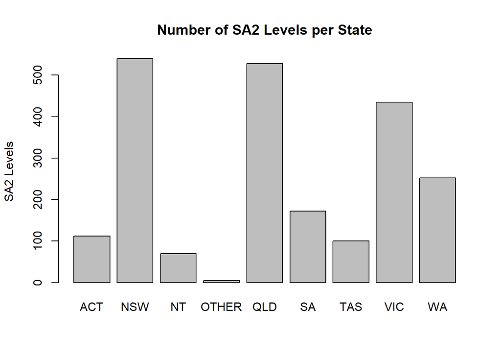

```r
# Histogram with number labels
Histogram <- function(data, x, xaxislabel) {
  attach(data)
  aggregateData <- aggregate(Count ~ x , FUN = sum, data=data)

  # Move rows with 100 years and over to end of the data frame
  bind <- aggregateData$x == "100 years and over"
  aggregateData <- rbind(aggregateData[!bind,], aggregateData[bind,])
  aggregateData$x <- as.character(aggregateData$x)
  aggregateData$x <- factor(aggregateData$x, levels=unique(aggregateData$x))
  detach(data)

  ggplot(data=aggregateData, aes(x=x , y=Count)) + geom_bar(colour="black", stat="identity") +
  geom_text(aes(label=Count), vjust=-0.5, color="black", fontface = "bold", size=4) +
  labs(x=xaxislabel,y="Count") + theme_classic()
}

# Histrogram Percentage
HistogramPercent <- function(data, x, xaxislabel, yaxislimits=c(0,40)) {
  total <- sum(data$Count)
  custom <- function(x) {(sum(x)/total)*100}

  attach(data)
  aggregateData <- aggregate(Count ~ x , FUN = custom, data=data)
  detach(data)

  ggplot(data=aggregateData, aes(x=x , y=Count)) + geom_bar(colour="black", stat="identity") +
  geom_text(aes(label=sprintf("%0.2f", round(Count, digits = 2))),
            vjust=-0.5, color="black", fontface = "bold", size=4) +
  scale_y_continuous(limits = yaxislimits) +
  labs(x=xaxislabel,y="Population %") + theme_classic()
}

# 2011 Census Data
plot(sa2Data2011$State, main="Number of SA2 Levels per State", ylab="SA2 Levels")
```

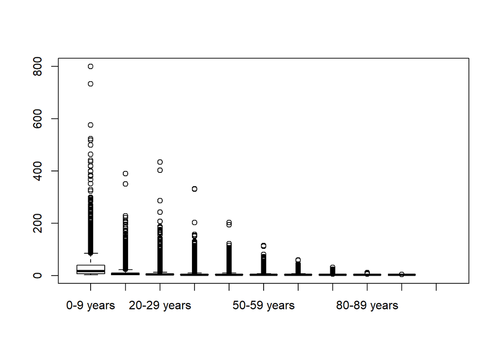

```r
boxplot(Count ~ Age, data = censusIndigenous2011)
```

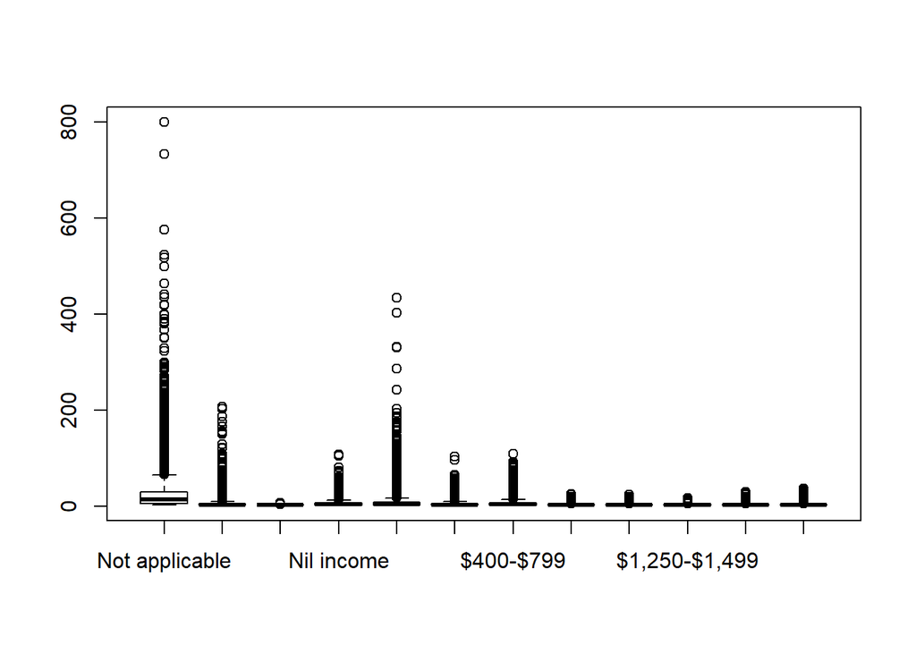

```r
boxplot(Count ~ Income, data = censusIndigenous2011)
```

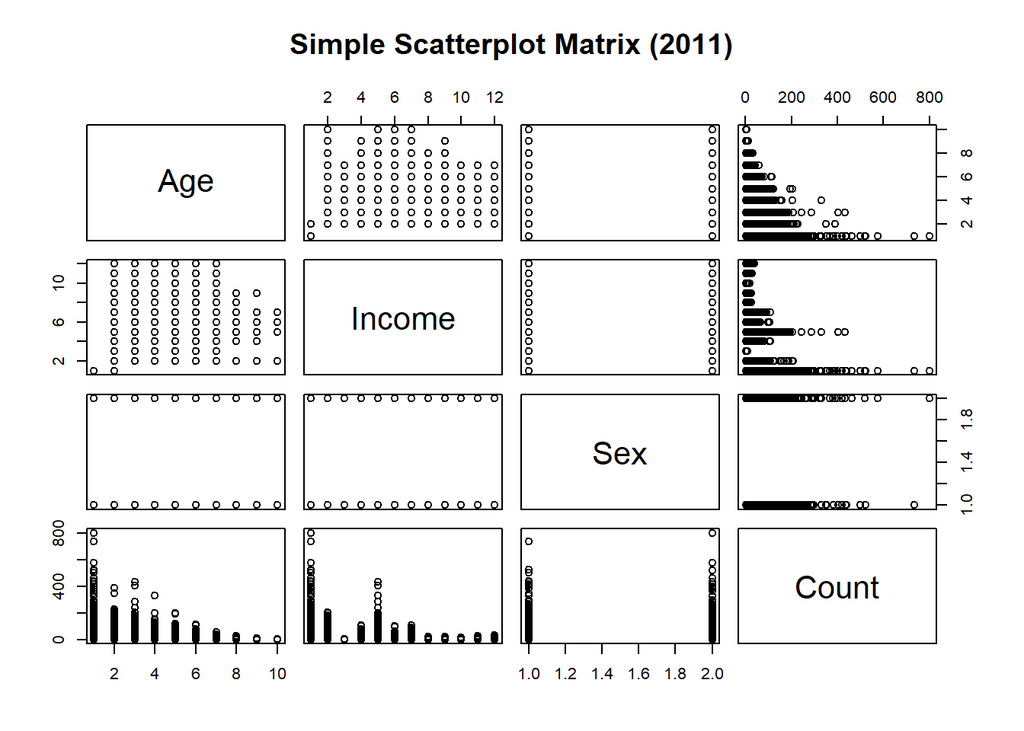

```r
pairs(~Age+Income+Sex+Count, data=censusIndigenous2011, main="Simple Scatterplot Matrix (2011)")
```

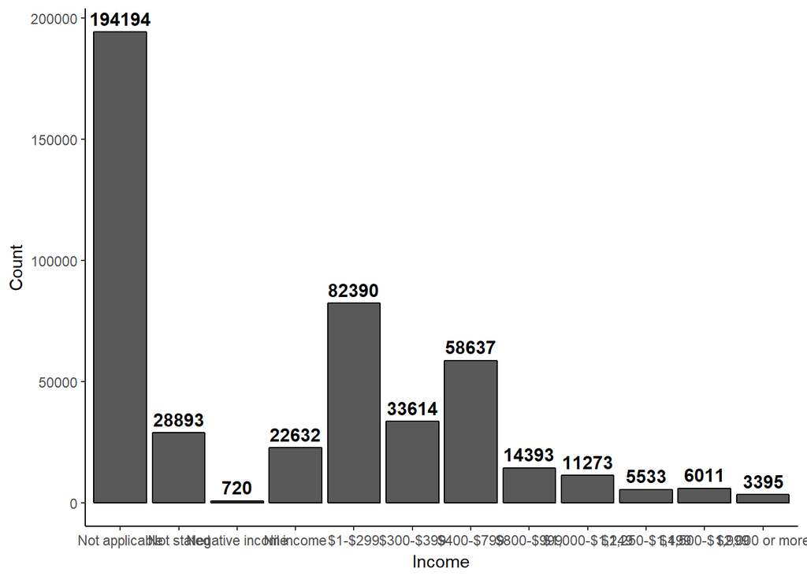

```r
Histogram(censusIndigenous2011, Income, "Income")
```

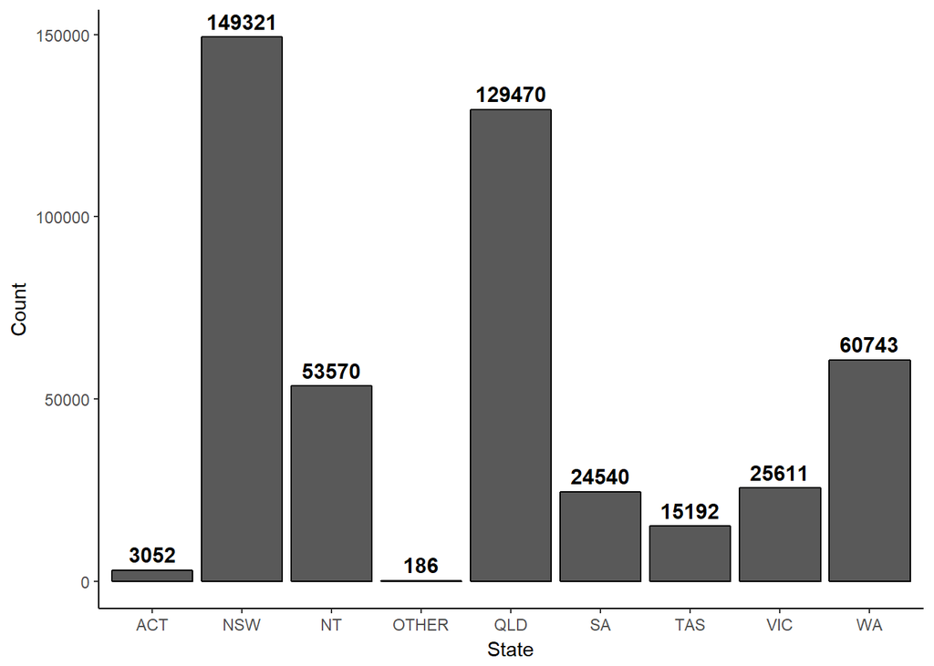

```r
Histogram(censusIndigenous2011, State, "State")
```

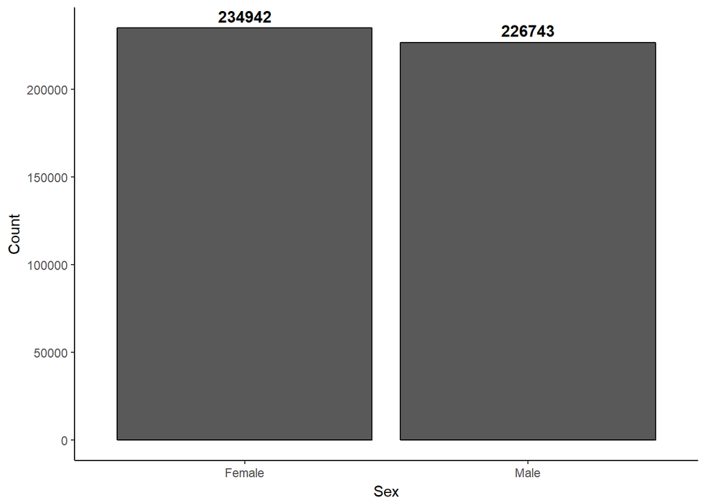

```r
Histogram(censusIndigenous2011, Sex, "Sex")
```

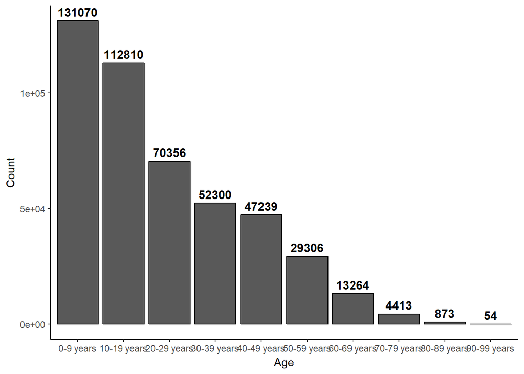

```r
Histogram(censusIndigenous2011, Age, "Age")
```

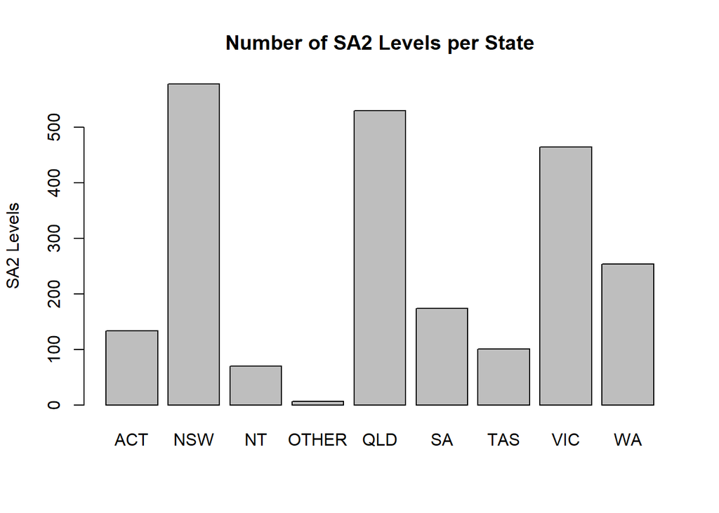

```r
# 2016 Census Data - Indigenous
plot(sa2Data2016$State, main="Number of SA2 Levels per State", ylab="SA2 Levels")
```

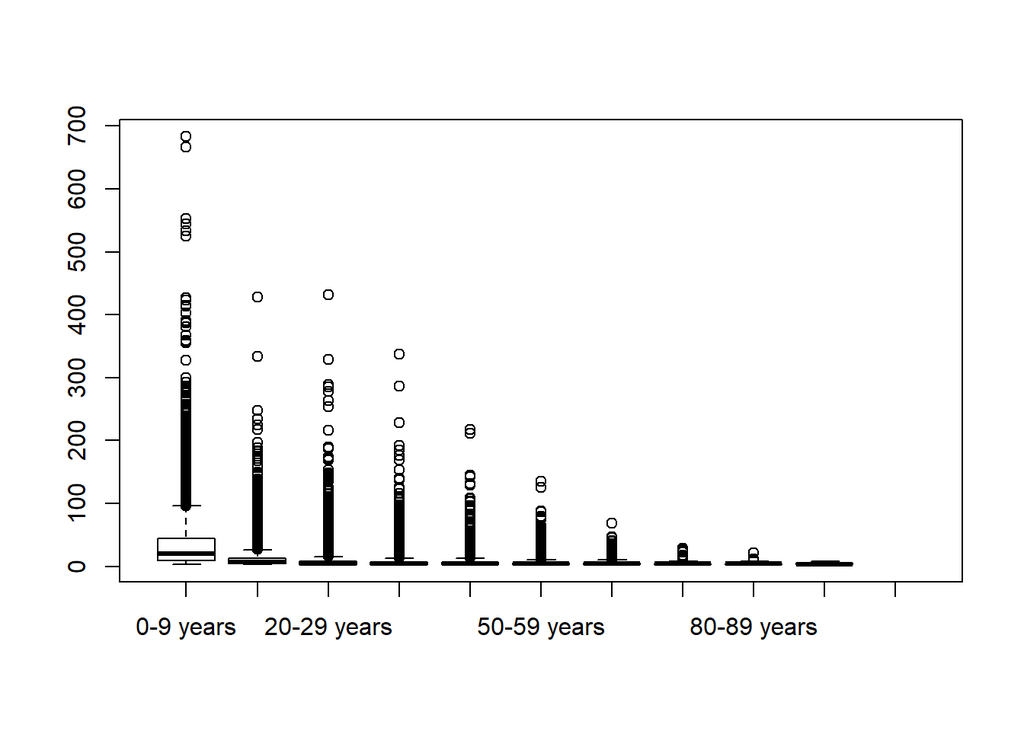

```r
boxplot(Count ~ Age, data = censusIndigenous2016)
```

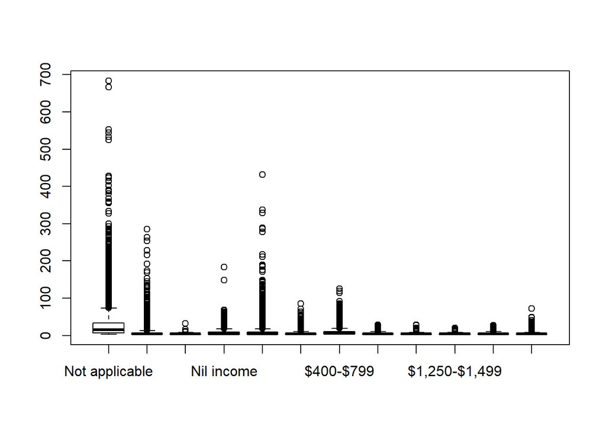

```r
boxplot(Count ~ Income, data = censusIndigenous2016)
```

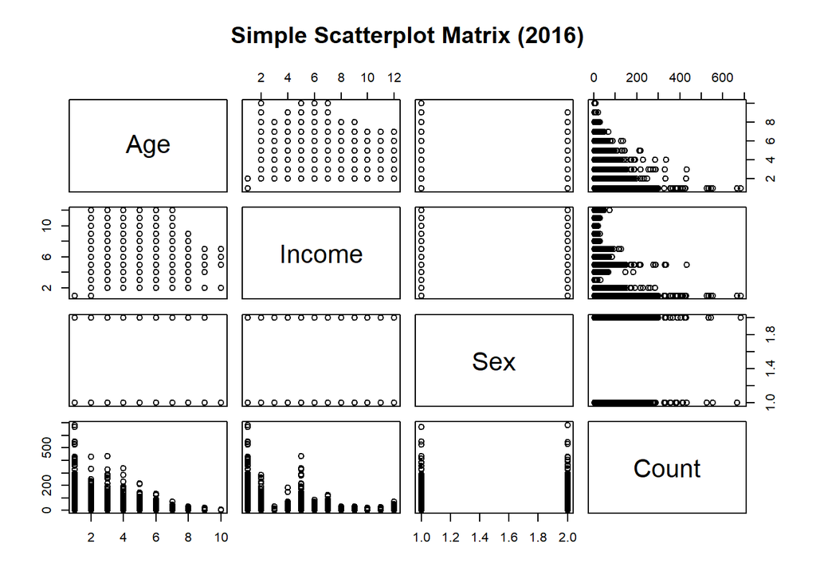

```r
pairs(~Age+Income+Sex+Count, data=censusIndigenous2016, main="Simple Scatterplot Matrix (2016)")
```

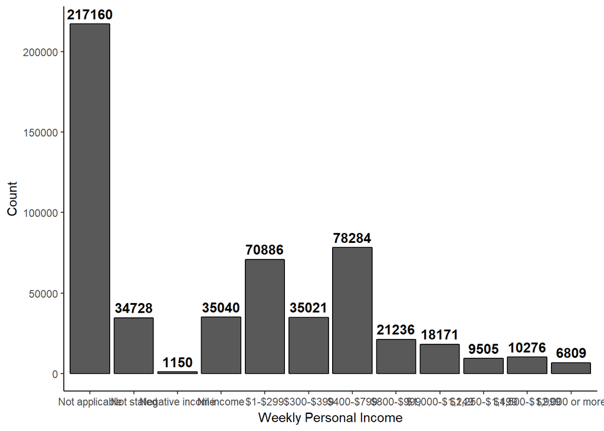

```r
Histogram(censusIndigenous2016, Income, "Weekly Personal Income")
```

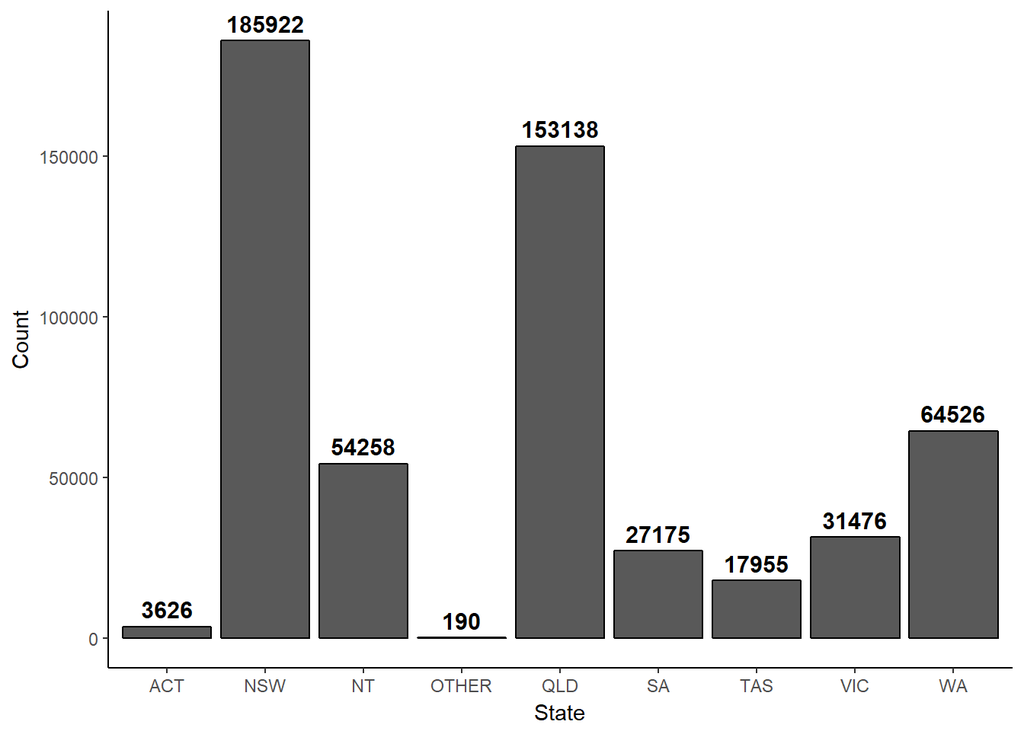

```r
Histogram(censusIndigenous2016, State, "State")
```

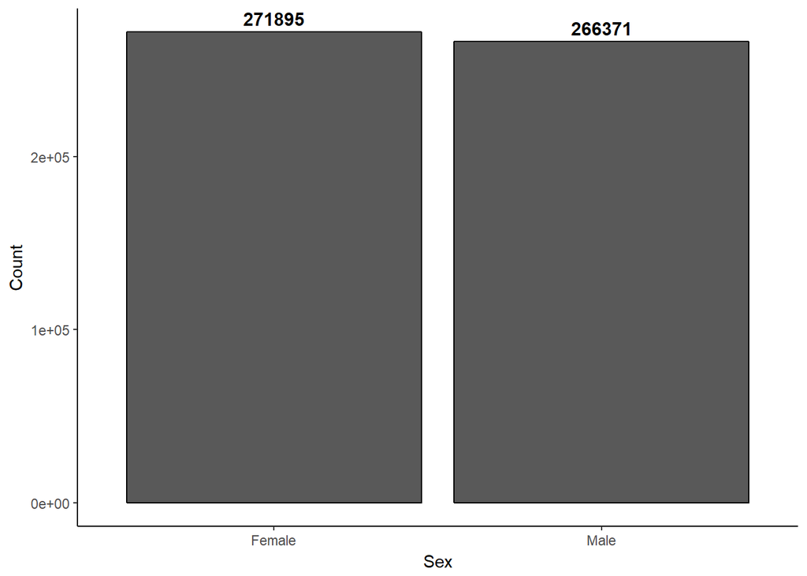

```r
Histogram(censusIndigenous2016, Sex, "Sex")
```

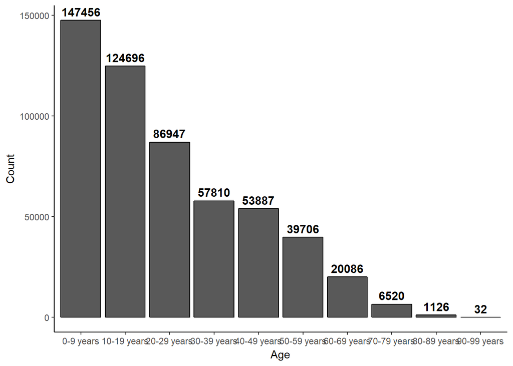

```r
Histogram(censusIndigenous2016, Age, "Age")
```

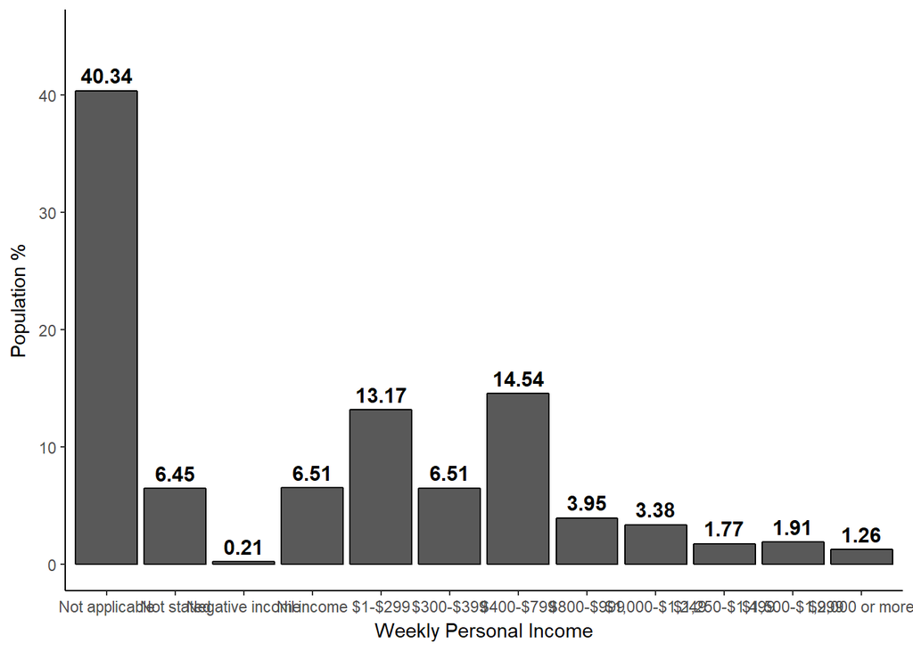

```r
HistogramPercent(censusIndigenous2016, Income, "Weekly Personal Income", c(0, 45))
```

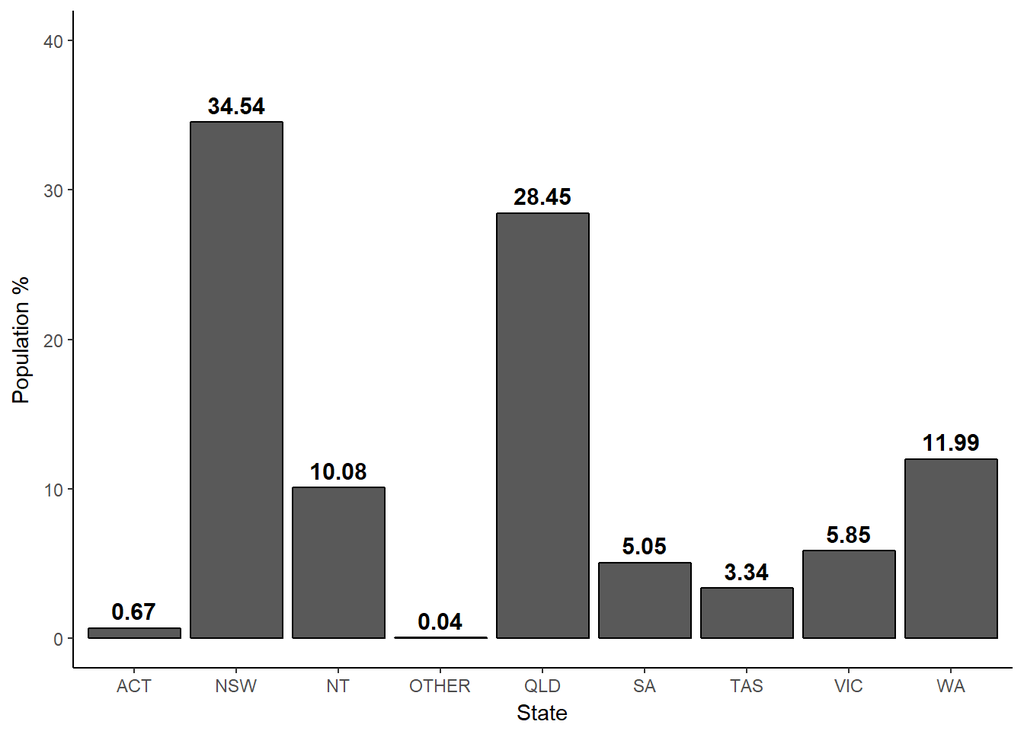

```r
HistogramPercent(censusIndigenous2016, State, "State")
```

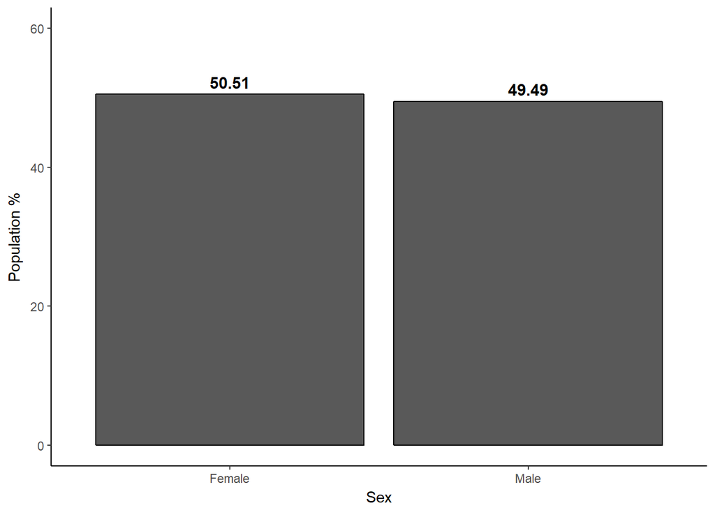

```r
HistogramPercent(censusIndigenous2016, Sex, "Sex", c(0, 60))
```

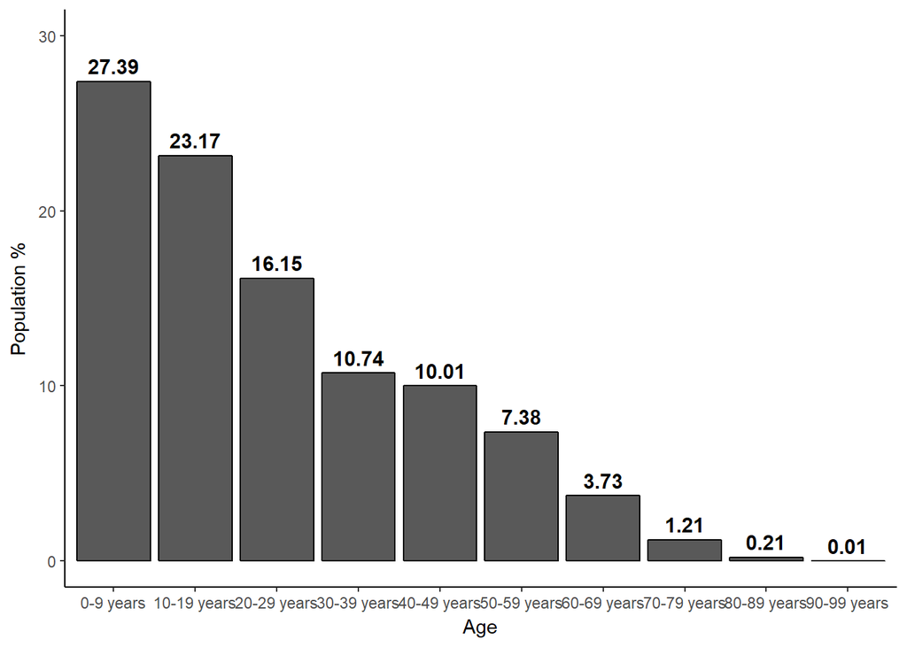

```r
HistogramPercent(censusIndigenous2016, Age, "Age", c(0,30))
```

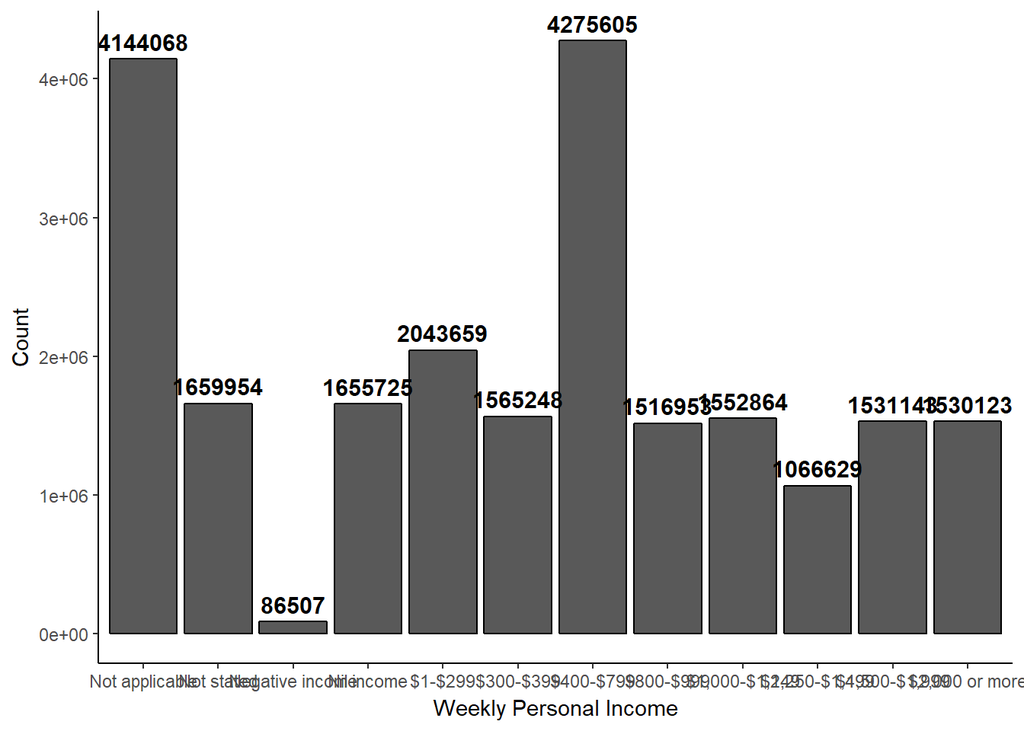

```r
# 2016 Census Data - Non-Indigenous
censusNonIndigenous2016 <- census2016[census2016$Indigenous==0,]
Histogram(censusNonIndigenous2016, Income, "Weekly Personal Income")
```

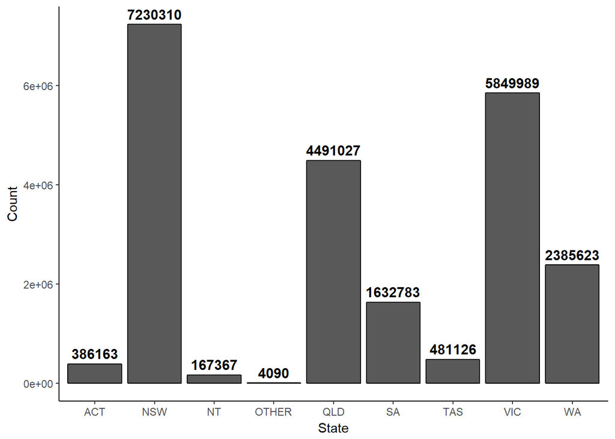

```r
Histogram(censusNonIndigenous2016, State, "State")
```

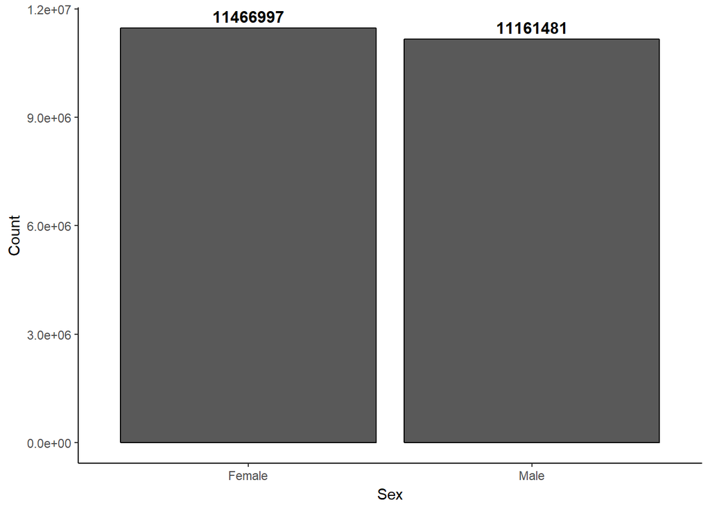

```r
Histogram(censusNonIndigenous2016, Sex, "Sex")
```

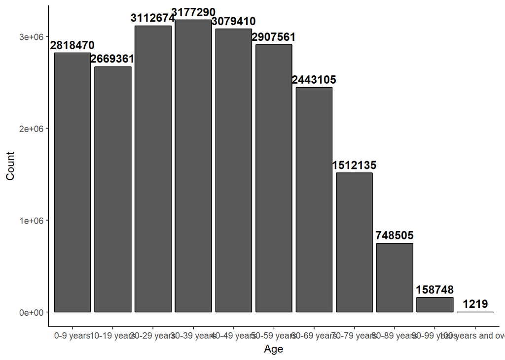

```r
Histogram(censusNonIndigenous2016, Age, "Age")
```

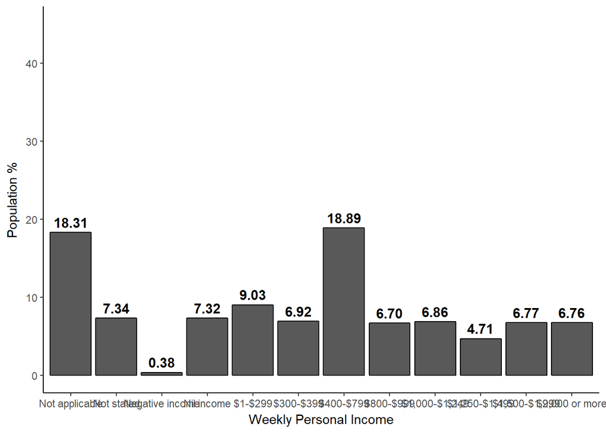

```r
HistogramPercent(censusNonIndigenous2016, Income, "Weekly Personal Income", c(0, 45))
```

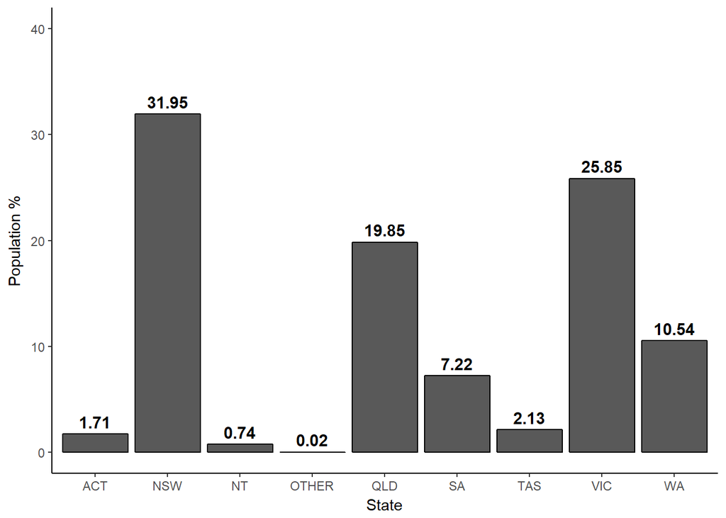

```r
HistogramPercent(censusNonIndigenous2016, State, "State")
```

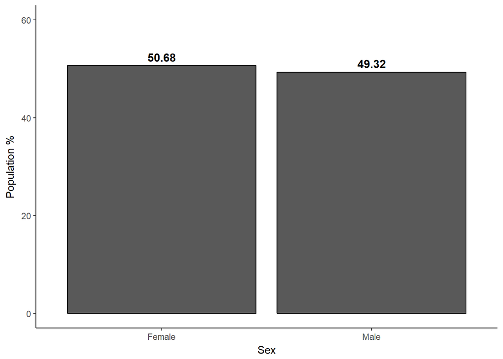

```r
HistogramPercent(censusNonIndigenous2016, Sex, "Sex", c(0, 60))
```

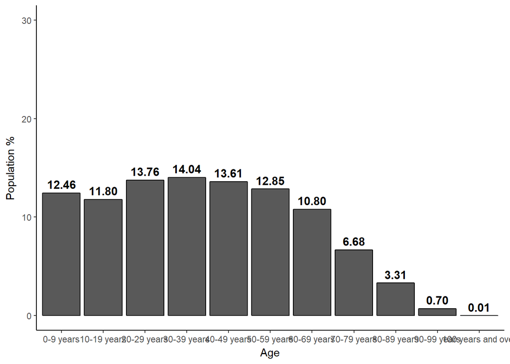

```r
HistogramPercent(censusNonIndigenous2016, Age, "Age", c(0,30))
```

```r
rm(Histogram, HistogramPercent)
```

# Normality Tests

In this section the normality of count data for the Indigenous population (2011) is examined.

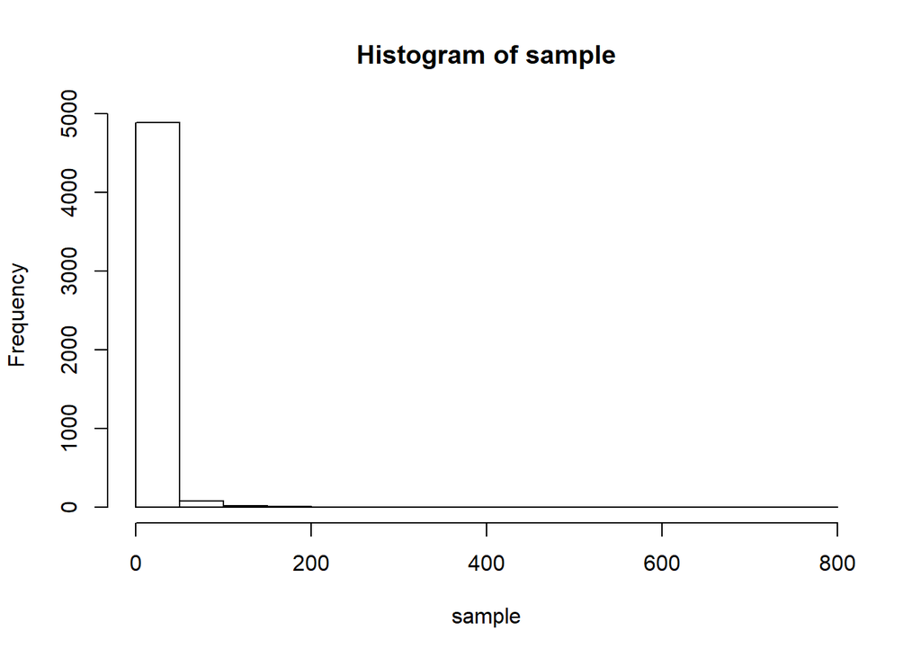

```r
# https://www.r-bloggers.com/normality-tests-for-continuous-data/
# http://stat.ethz.ch/R-manual/R-devel/library/stats/html/shapiro.test.html

data <- censusIndigenous2011$Count
sample <- sample(data, size = 5000)
hist(sample)
```

```r
shapiro.test(sample) # Sample size must be between 3 and 5000
```

```
##
##  Shapiro-Wilk normality test
##
## data:  sample
## W = 0.23204, p-value < 2.2e-16
```

```r
library(nortest)
# The A-D test is susceptible to extreme values, and may not give good results for very large data sets
ad.test(data) # very low p-value indicates that the distribution is not normal
```

```
##
##  Anderson-Darling normality test
##
## data:  data
## A = 9994.7, p-value < 2.2e-16
```

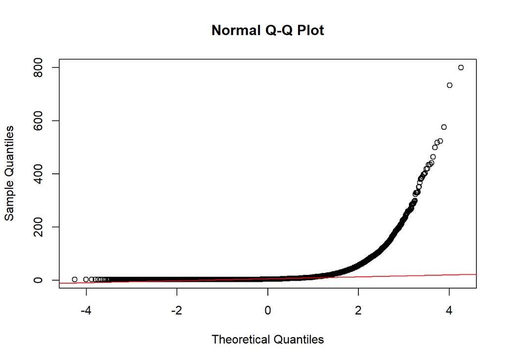

```r
qqnorm(data)
qqline(data, col = "red")
```

```r
rm(data, sample)
```

# Transformation

For techniques such as correlation analysis and regression analysis a normal distribution is required. Because the population counts are not normal the data needs to be transformed.

If distribution is right-skewed: sqrt(x); log(x); 1/sqrt(x); 1/x

```r
# Transformations: http://rcompanion.org/handbook/I_12.html

library(MASS)
Box = boxcox(censusIndigenous2011$Count ~ 1,              # Transform Turbidity as a single vector
             lambda = seq(-6,6,0.1)      # Try values -6 to 6 by 0.1
             )
```

[figure not shown]

```r
Cox = data.frame(Box$x, Box$y)            # Create a data frame with the results
Cox2 = Cox[with(Cox, order(-Cox$Box.y)),] # Order the new data frame by decreasing y
Cox2[1,]                                  # Display the lambda with the greatest
```

```
##    Box.x     Box.y
## 51    -1 -238635.6
```

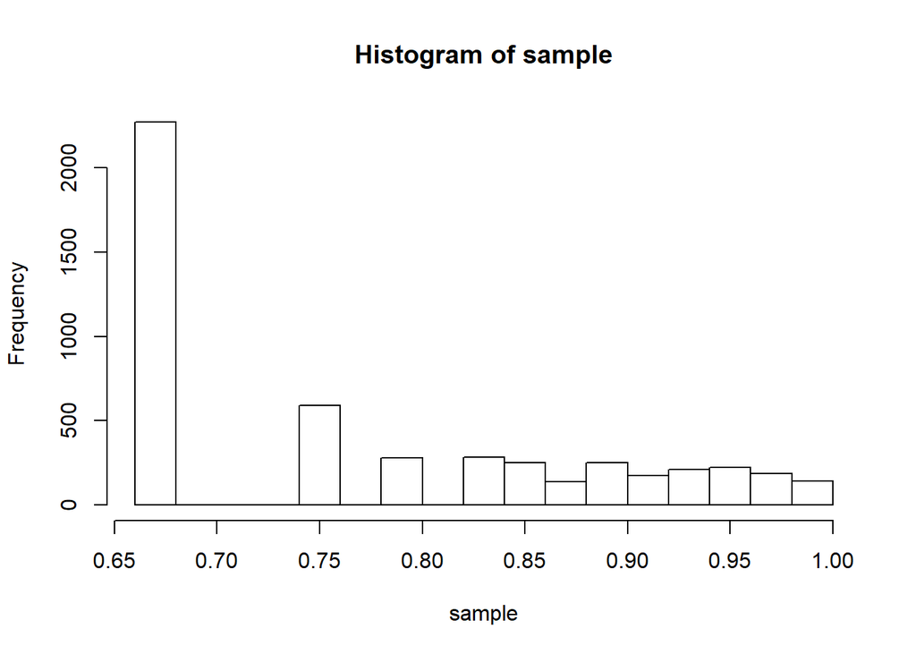

```r
                                          #    log likelihood
lambda = Cox2[1, "Box.x"]                 # Extract that lambda
censusIndigenous2011$TransformedCount = (censusIndigenous2011$Count ^ lambda - 1)/lambda #Transform the original data

#censusIndigenous2011$TransformedCount <- log(censusIndigenous2011$Count)
#censusIndigenous2011$TransformedCount <- sqrt(censusIndigenous2011$Count)
#censusIndigenous2011$TransformedCount <- 1/sqrt(censusIndigenous2011$Count)
#censusIndigenous2011$TransformedCount <- 1/censusIndigenous2011$Count
#censusIndigenous2011$TransformedCount <- sign(censusIndigenous2011$Count) * abs(censusIndigenous2011$Count)^(1/3)

data <- censusIndigenous2011$TransformedCount
sample <- sample(data, size = 5000)
hist(sample)
```

```r
shapiro.test(sample) # Sample size must be between 3 and 5000
```

```
##
##  Shapiro-Wilk normality test
##
## data:  sample
## W = 0.82148, p-value < 2.2e-16
```

```r
# The A-D test is susceptible to extreme values, and may not give good results for very large data sets
ad.test(censusIndigenous2011$TransformedCount) # very low p-value indicates that the distribution is not normal
```

```
##
##  Anderson-Darling normality test
##
## data:  censusIndigenous2011$TransformedCount
## A = 3334.5, p-value < 2.2e-16
```

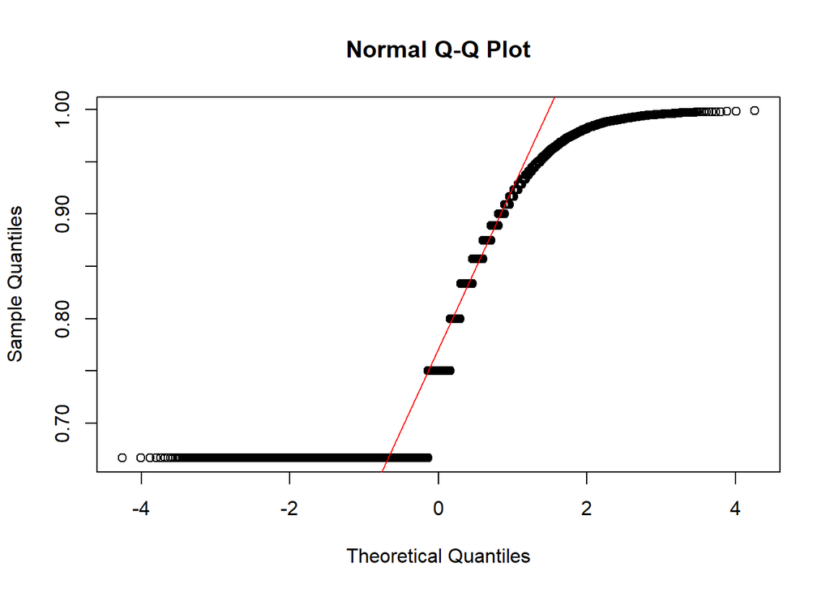

```r
qqnorm(data)
qqline(data, col = "red")
```

```r
rm(Cox, Cox2, Box, data, lambda, sample)
```

# Correlation

In this section the correlation between variables for the Indigenous population are examined.

```r
# https://stats.stackexchange.com/questions/108007/correlations-with-unordered-categorical-variables
# https://stats.stackexchange.com/questions/119835/correlation-between-a-nominal-iv-and-a-continuous-dv-variable/124618#124618

# Correlation for 2011 Census data only

  #library(corrgram)
  #corrgram(censusIndigenous2011, order=TRUE, lower.panel=panel.shade,
  #         upper.panel=NULL, text.panel=panel.txt, cor.method = "spearman",
  #         main="Correlation of Numerical Variables")

  #corrgram(censusIndigenous2011, order=TRUE, lower.panel=panel.shade,
  #         upper.panel=NULL, text.panel=panel.txt, cor.method = "pearson",
  #         main="Correlation of Numerical Variables")

  nums <- sapply(censusIndigenous2011, is.numeric)
  numeric_data <- censusIndigenous2011[ , nums]

  # calculate correlation matrix
  spearman <- cor(numeric_data, use="complete.obs", method="spearman") # can be used when outliers present
  pearson <- cor(numeric_data, use="complete.obs", method="pearson")  # assumes normality
  # summarise the correlation matrix
  print(spearman)
```

```
##                                   City InnerRegional OuterRegional
## City                       1.000000000  -0.367395199 -0.5196332599
## InnerRegional             -0.367395199   1.000000000 -0.1157098728
## OuterRegional             -0.519633260  -0.115709873  1.0000000000
## Remote                    -0.360942742  -0.246092999  0.0003426881
## VeryRemote                -0.262695928  -0.190050607 -0.1349475170
## MigratoryOffshoreShipping           NA            NA            NA
## NoUsualAddress            -0.065571808  -0.047438733 -0.0453955547
## StatePopulation            0.166703998   0.209953175 -0.0794433904
## SA2Population              0.497750310   0.046856506 -0.3402511953
## ACT                        0.130734419  -0.071954297 -0.0692411853
## NSW                        0.120403005   0.152468169 -0.0592670182
## NT                        -0.223496832  -0.161691537  0.0812795273
## OTHER                     -0.022311666   0.037420238 -0.0154464315
## QLD                       -0.052921798  -0.025896209  0.0822269079
## SA                         0.071948873  -0.095332561 -0.0268319885
## TAS                       -0.188658082   0.134670984  0.1223349678
## VIC                        0.045108492   0.106521062 -0.0685394563
## WA                         0.047117195  -0.147475412 -0.0596055205
## 0-9 years                  0.073679913   0.005876855 -0.0347437048
## 10-19 years                0.044502740   0.022928325 -0.0175045065
## 20-29 years                0.033987902  -0.020239362 -0.0241473670
## 30-39 years               -0.008145320  -0.006799630 -0.0013143537
## 40-49 years               -0.020011061  -0.002335199  0.0160687202
## 50-59 years               -0.052657481   0.002000617  0.0308490407
## 60-69 years               -0.059771785   0.005564232  0.0328174369
## 70-79 years               -0.051629834  -0.001463841  0.0241751124
## 80-89 years               -0.038058354  -0.017622063 -0.0042177207
## 90-99 years               -0.015774121  -0.008887468 -0.0057698372
## 100 years and over                  NA            NA            NA
## Not applicable             0.095502837   0.014778955 -0.0425068902
## Not stated                -0.058000225  -0.007891092  0.0156471248
## Negative income           -0.013077566  -0.002648965  0.0097372440
## Nil income                -0.008212021  -0.001596667 -0.0029317853
## $1-$299                   -0.022331187   0.015793245  0.0199404637
## $300-$399                 -0.052476003   0.009889814  0.0325813428
## $400-$799                  0.004615810   0.010945254  0.0057941310
## $800-$999                  0.008230040  -0.009079509 -0.0038126473
## $1,000-$1,249              0.021744050  -0.022592938 -0.0163216062
## $1,250-$1,499              0.002282264  -0.019461869 -0.0038552949
```

[output cut: 605 more lines]

```
## 100 years and over                    NA           NA               NA
## Not applicable              -0.054527335  0.392534013      0.392534013
## Not stated                  -0.040530058 -0.054454989     -0.054454989
## Negative income             -0.008873586 -0.053055070     -0.053055070
## Nil income                  -0.036911324 -0.026770469     -0.026770469
## $1-$299                     -0.063253664  0.039992481      0.039992481
## $300-$399                   -0.050486934 -0.089191809     -0.089191809
## $400-$799                   -0.058205398  0.027670958      0.027670958
## $800-$999                   -0.036281334 -0.118989611     -0.118989611
## $1,000-$1,249               -0.032891934 -0.130060118     -0.130060118
## $1,250-$1,499               -0.023715835 -0.114502994     -0.114502994
## $1,500-$1,999               -0.023940140 -0.102738540     -0.102738540
## $2,000 or more               1.000000000 -0.076037113     -0.076037113
## Count                       -0.076037113  1.000000000      1.000000000
## TransformedCount            -0.076037113  1.000000000      1.000000000
```

```r
  print(pearson)
```

```
##                                   City InnerRegional OuterRegional
## City                       1.000000000  -0.367395199 -0.5196332599
## InnerRegional             -0.367395199   1.000000000 -0.1157098728
## OuterRegional             -0.519633260  -0.115709873  1.0000000000
## Remote                    -0.360942742  -0.246092999  0.0003426881
## VeryRemote                -0.262695928  -0.190050607 -0.1349475170
## MigratoryOffshoreShipping           NA            NA            NA
## NoUsualAddress            -0.065571808  -0.047438733 -0.0453955547
## StatePopulation            0.172368819   0.201885486 -0.0778397774
## SA2Population              0.482575335   0.015932674 -0.3276526351
## ACT                        0.130734419  -0.071954297 -0.0692411853
## NSW                        0.120403005   0.152468169 -0.0592670182
## NT                        -0.223496832  -0.161691537  0.0812795273
## OTHER                     -0.022311666   0.037420238 -0.0154464315
## QLD                       -0.052921798  -0.025896209  0.0822269079
## SA                         0.071948873  -0.095332561 -0.0268319885
## TAS                       -0.188658082   0.134670984  0.1223349678
## VIC                        0.045108492   0.106521062 -0.0685394563
## WA                         0.047117195  -0.147475412 -0.0596055205
## 0-9 years                  0.073679913   0.005876855 -0.0347437048
## 10-19 years                0.044502740   0.022928325 -0.0175045065
## 20-29 years                0.033987902  -0.020239362 -0.0241473670
## 30-39 years               -0.008145320  -0.006799630 -0.0013143537
## 40-49 years               -0.020011061  -0.002335199  0.0160687202
## 50-59 years               -0.052657481   0.002000617  0.0308490407
## 60-69 years               -0.059771785   0.005564232  0.0328174369
## 70-79 years               -0.051629834  -0.001463841  0.0241751124
## 80-89 years               -0.038058354  -0.017622063 -0.0042177207
## 90-99 years               -0.015774121  -0.008887468 -0.0057698372
## 100 years and over                  NA            NA            NA
## Not applicable             0.095502837   0.014778955 -0.0425068902
## Not stated                -0.058000225  -0.007891092  0.0156471248
## Negative income           -0.013077566  -0.002648965  0.0097372440
## Nil income                -0.008212021  -0.001596667 -0.0029317853
## $1-$299                   -0.022331187   0.015793245  0.0199404637
## $300-$399                 -0.052476003   0.009889814  0.0325813428
## $400-$799                  0.004615810   0.010945254  0.0057941310
## $800-$999                  0.008230040  -0.009079509 -0.0038126473
## $1,000-$1,249              0.021744050  -0.022592938 -0.0163216062
## $1,250-$1,499              0.002282264  -0.019461869 -0.0038552949
```

[output cut: 605 more lines]

```
## 100 years and over                    NA           NA               NA
## Not applicable              -0.054527335  0.362973750      0.407209809
## Not stated                  -0.040530058 -0.040016670     -0.056570975
## Negative income             -0.008873586 -0.020690027     -0.052879679
## Nil income                  -0.036911324 -0.043040994     -0.029652231
## $1-$299                     -0.063253664 -0.011019449      0.039501286
## $300-$399                   -0.050486934 -0.077671190     -0.094122910
## $400-$799                   -0.058205398 -0.046309871      0.028579496
## $800-$999                   -0.036281334 -0.072102941     -0.123266711
## $1,000-$1,249               -0.032891934 -0.068415905     -0.132730261
## $1,250-$1,499               -0.023715835 -0.052221884     -0.115773031
## $1,500-$1,999               -0.023940140 -0.050548843     -0.104182576
## $2,000 or more               1.000000000 -0.035009985     -0.077214798
## Count                       -0.035009985  1.000000000      0.500001338
## TransformedCount            -0.077214798  0.500001338      1.000000000
```

```r
  rm(nums, numeric_data, spearman, pearson)
```

# Regression

Multiple linear regression is used to get a better understanding of which variables are important in estimating the number of indigenous people.

Assumptions for multiple linear regression: * Error terms must be Normally distributed * Linearity: The relationship between y and x is linear * Independent errors: the residuals are independent ** In particular, repeated observations on the same individual are not allowed * Normality: the residuals are Normally distributed for any given value of x - use a P-P or Q-Q Plot * Equal Variance (homoscedasticity): the residuals have constant variance around the 0 line

These assumptions can be checked using plots. If assumptions have been violated, findings cannot be generalised beyond the sample.

A good model has a large F-ratio and a small P-value

In multiple regression, R2 is the square of the multiple correlation coefficient between the dependent variable and the predictors. The adjusted R2 indicates the loss of predictive power or shrinkage

Binary logistic regression: Used to predict a binary (dichotomous) categorical response variable from one or more categorical and/or continuous explanatory variables

```r
# https://www.statmethods.net/stats/regression.html
# https://data-flair.training/blogs/r-nonlinear-regression/
# Regression for Count data: http://rcompanion.org/handbook/J_01.html
# Survey package: https://cran.r-project.org/web/packages/survey/survey.pdf

library(car)
library(multcompView)
library(lsmeans)
library(rcompanion)
library(boot)
library(MASS)

# Regression for count data (generalised linear regression)
# Generalised linear models are used when the dependent variable is count, binary, multinomial, etc.
# Did not include "No Usual Address" and "MigratoryOffshoreShipping" due to zero or low population counts
# Did not include "Sex" as split between male and female is ~50%
glmFit <- glm(Count ~ State + Age + Income + City + InnerRegional + OuterRegional + Remote + VeryRemote
              + StatePopulation + SA2Population, data = censusIndigenous2011)
glmFit$family # The family object used
```

```
##
## Family: gaussian
## Link function: identity
```

```r
step <- stepAIC(glmFit, direction="both")
```

```
## Start:  AIC=415173
## Count ~ State + Age + Income + City + InnerRegional + OuterRegional +
##     Remote + VeryRemote + StatePopulation + SA2Population
##
##
## Step:  AIC=415173
## Count ~ State + Age + Income + City + InnerRegional + OuterRegional +
##     Remote + VeryRemote + SA2Population
##
##                 Df Deviance    AIC
## <none>             15046089 415173
## - OuterRegional  1 15049488 415182
## - Remote         1 15058525 415211
## - InnerRegional  1 15069544 415246
## - City           1 15234552 415773
## - VeryRemote     1 15241494 415796
## - SA2Population  1 15348227 416133
## - State          8 15400241 416283
## - Age            9 15674191 417134
## - Income        11 15692200 417186
```

```r
step$anova # display results
```

```
## Stepwise Model Path
## Analysis of Deviance Table
##
## Initial Model:
## Count ~ State + Age + Income + City + InnerRegional + OuterRegional +
##     Remote + VeryRemote + StatePopulation + SA2Population
##
## Final Model:
## Count ~ State + Age + Income + City + InnerRegional + OuterRegional +
##     Remote + VeryRemote + SA2Population
##
##
##                Step Df Deviance Resid. Df Resid. Dev    AIC
## 1                                   48360   15046089 415173
## 2 - StatePopulation  0        0     48360   15046089 415173
```

```r
# Diagnostics
anova(glmFit)
```

```
## Analysis of Deviance Table
##
## Model: gaussian, link: identity
##
## Response: Count
##
## Terms added sequentially (first to last)
##
##
##                 Df Deviance Resid. Df Resid. Dev
## NULL                            48394   20089350
## State            8   290511     48386   19798839
## Age              9  3080651     48377   16718187
## Income          11   531286     48366   16186901
## City             1   300846     48365   15886056
## InnerRegional    1    83096     48364   15802959
## OuterRegional    1   216001     48363   15586959
## Remote           1   102582     48362   15484376
## VeryRemote       1   136149     48361   15348227
## StatePopulation  0        0     48361   15348227
## SA2Population    1   302139     48360   15046089
```

```r
summary(glmFit)
```

```
##
## Call:
## glm(formula = Count ~ State + Age + Income + City + InnerRegional +
##     OuterRegional + Remote + VeryRemote + StatePopulation + SA2Population,
##     data = censusIndigenous2011)
##
## Deviance Residuals:
##    Min      1Q  Median      3Q     Max
## -47.88   -5.22   -0.84    3.18  741.32
##
## Coefficients: (1 not defined because of singularities)
##                         Estimate Std. Error t value Pr(>|t|)
## (Intercept)            3.247e+01  8.059e-01  40.287  < 2e-16 ***
## StateNSW               3.702e+00  7.439e-01   4.977 6.49e-07 ***
## StateNT                8.917e+00  8.018e-01  11.122  < 2e-16 ***
## StateOTHER             2.131e+00  3.204e+00   0.665  0.50605
## StateQLD               3.707e+00  7.364e-01   5.034 4.83e-07 ***
## StateSA                2.338e-01  7.899e-01   0.296  0.76725
## StateTAS               6.635e-01  8.210e-01   0.808  0.41898
## StateVIC              -4.649e+00  7.864e-01  -5.912 3.40e-09 ***
## StateWA                2.845e+00  7.564e-01   3.760  0.00017 ***
## Age10-19 years        -1.659e+01  4.197e-01 -39.522  < 2e-16 ***
## Age20-29 years        -1.568e+01  5.177e-01 -30.277  < 2e-16 ***
## Age30-39 years        -1.684e+01  5.276e-01 -31.928  < 2e-16 ***
## Age40-49 years        -1.755e+01  5.269e-01 -33.313  < 2e-16 ***
## Age50-59 years        -1.920e+01  5.409e-01 -35.489  < 2e-16 ***
## Age60-69 years        -2.123e+01  5.905e-01 -35.954  < 2e-16 ***
## Age70-79 years        -2.319e+01  7.381e-01 -31.425  < 2e-16 ***
## Age80-89 years        -2.747e+01  1.284e+00 -21.396  < 2e-16 ***
## Age90-99 years        -3.249e+01  4.441e+00  -7.317 2.57e-13 ***
## IncomeNot stated      -1.521e+01  4.549e-01 -33.443  < 2e-16 ***
## IncomeNegative income -1.973e+01  1.234e+00 -15.980  < 2e-16 ***
## IncomeNil income      -1.521e+01  4.395e-01 -34.618  < 2e-16 ***
## Income$1-$299         -1.123e+01  4.095e-01 -27.417  < 2e-16 ***
## Income$300-$399       -1.523e+01  4.477e-01 -34.025  < 2e-16 ***
## Income$400-$799       -1.313e+01  4.366e-01 -30.062  < 2e-16 ***
## Income$800-$999       -1.734e+01  5.039e-01 -34.413  < 2e-16 ***
## Income$1,000-$1,249   -1.762e+01  5.227e-01 -33.704  < 2e-16 ***
## Income$1,250-$1,499   -1.833e+01  6.088e-01 -30.108  < 2e-16 ***
## Income$1,500-$1,999   -1.792e+01  6.063e-01 -29.566  < 2e-16 ***
## Income$2,000 or more  -1.805e+01  7.388e-01 -24.426  < 2e-16 ***
## City                  -7.745e+00  3.147e-01 -24.612  < 2e-16 ***
## InnerRegional         -2.364e+00  2.722e-01  -8.683  < 2e-16 ***
## OuterRegional         -9.340e-01  2.826e-01  -3.305  0.00095 ***
## Remote                 2.323e+00  3.674e-01   6.322 2.60e-10 ***
## VeryRemote             1.112e+01  4.437e-01  25.061  < 2e-16 ***
## StatePopulation               NA         NA      NA       NA
## SA2Population          5.208e-04  1.671e-05  31.163  < 2e-16 ***
## ---
## Signif. codes:  0 '***' 0.001 '**' 0.01 '*' 0.05 '.' 0.1 ' ' 1
##
## (Dispersion parameter for gaussian family taken to be 311.1267)
##
##     Null deviance: 20089350  on 48394  degrees of freedom
## Residual deviance: 15046089  on 48360  degrees of freedom
## AIC: 415173
##
## Number of Fisher Scoring iterations: 2
```

```r
Anova(glmFit, type="II", test="LR")
```

```
## Analysis of Deviance Table (Type II tests)
##
## Response: Count
##                 LR Chisq Df Pr(>Chisq)
## State            1132.48  7  < 2.2e-16 ***
## Age              2018.80  9  < 2.2e-16 ***
## Income           2076.68 11  < 2.2e-16 ***
## City              605.74  1  < 2.2e-16 ***
## InnerRegional      75.39  1  < 2.2e-16 ***
## OuterRegional      10.92  1  0.0009492 ***
## Remote             39.97  1  2.579e-10 ***
## VeryRemote        628.06  1  < 2.2e-16 ***
## StatePopulation           0
## SA2Population     971.11  1  < 2.2e-16 ***
## ---
## Signif. codes:  0 '***' 0.001 '**' 0.01 '*' 0.05 '.' 0.1 ' ' 1
```

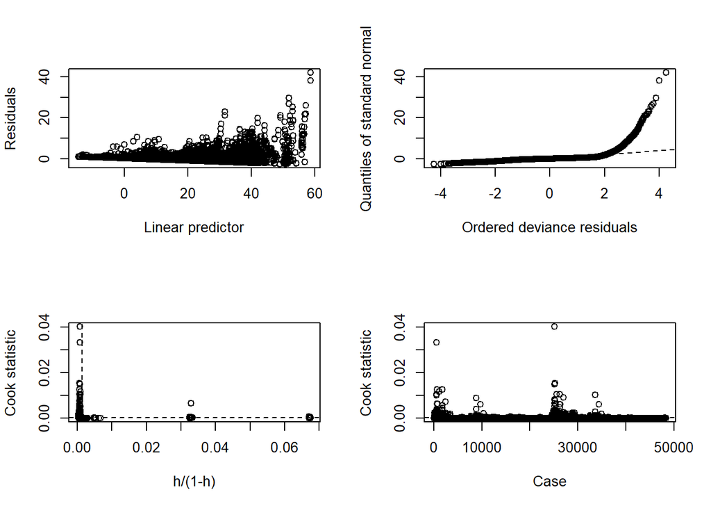

```r
fitDiag <- glm.diag(glmFit)
glm.diag.plots(glmFit, fitDiag)
```

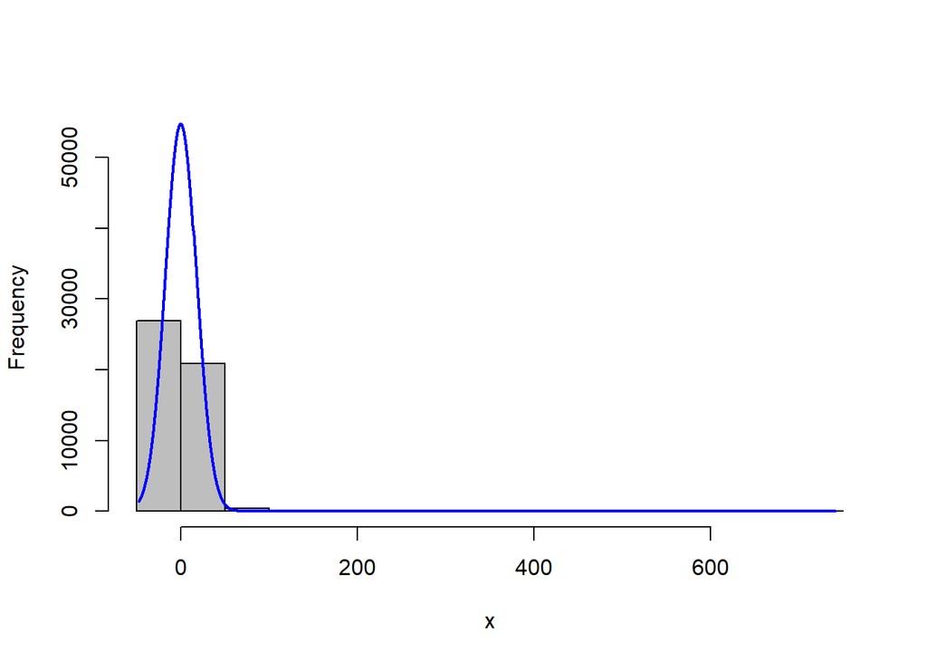

```r
x = residuals(glmFit)
plotNormalHistogram(x)
```

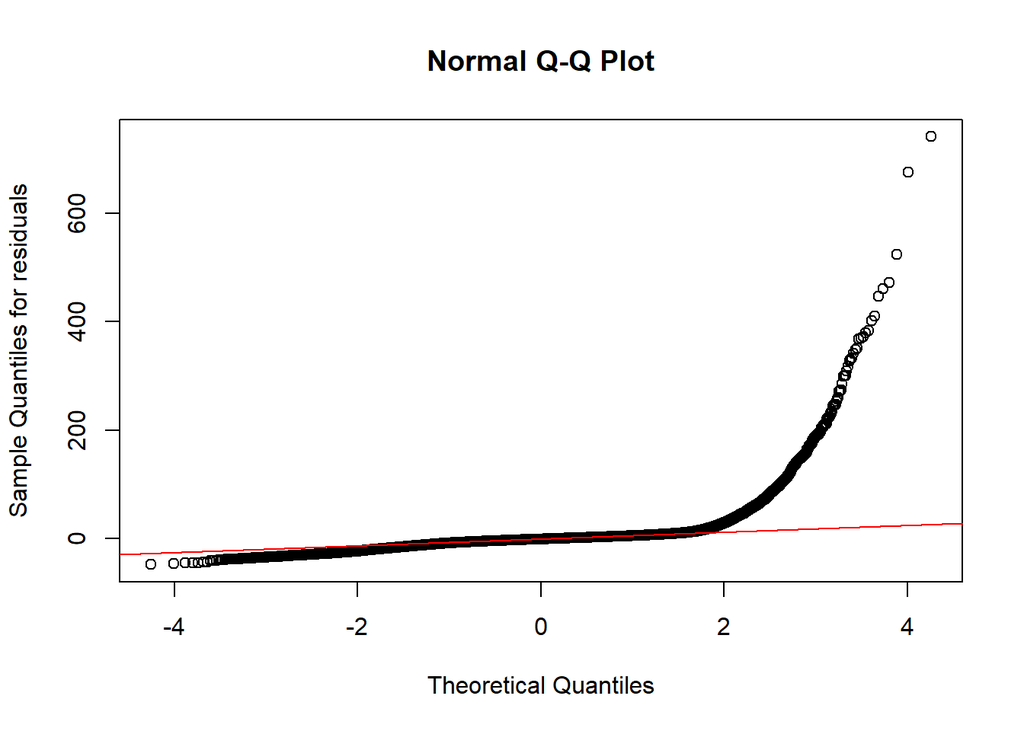

```r
qqnorm(residuals(glmFit), ylab="Sample Quantiles for residuals")
qqline(residuals(glmFit), col="red")
```

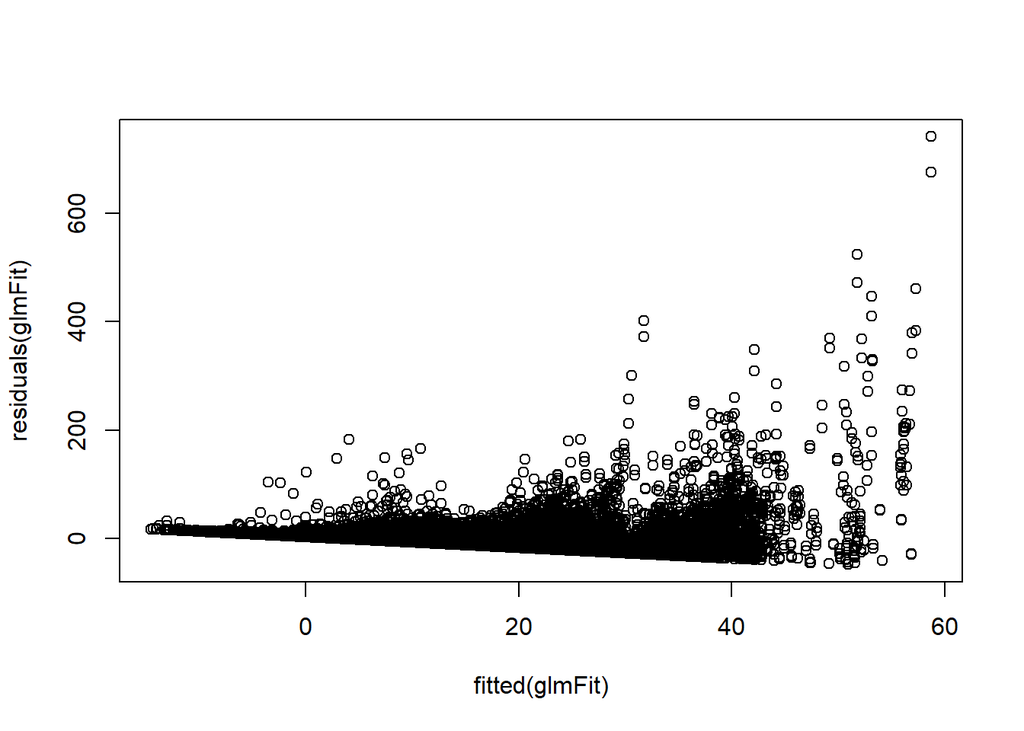

```r
plot(fitted(glmFit), residuals(glmFit))
```

```r
rm(step, x, glmFit)
```